# DANA4830

Sandaru / Laura / Julio / Diego

2024-11-24

```r
library(dplyr)
```

```r
library(ggplot2)
library(tidyr)
library(reshape2)
library(nnet)
library(caTools)
library(randomForest)
library(caret)
library(psych)
library(GPArotation)
library(FactoMineR)
library(factoextra)
library(pROC)
library(corrplot)
```

## Load data set

```r
flight_data <- read.csv("Dataset/final_winter_season_data.csv")
head(flight_data)
```

```
##   status departure.delay departure.scheduledTime departure.estimatedTime
## 1 active              13     2023-12-01 00:15:00     2023-12-01 00:15:00
## 2 active              13     2023-12-01 00:15:00     2023-12-01 00:15:00
## 3 active              13     2023-12-01 00:15:00     2023-12-01 00:15:00
## 4 active              13     2023-12-01 00:15:00     2023-12-01 00:15:00
## 5 active              19     2023-12-01 00:30:00     2023-12-01 00:33:00
## 6 active              17     2023-12-01 00:35:00     2023-12-01 00:35:00
##   departure.actualTime               airline.name temperature_2m precipitation
## 1  2023-12-01 00:28:00                 air canada            4.8           0.2
## 2  2023-12-01 00:28:00         singapore airlines            4.8           0.2
## 3  2023-12-01 00:28:00 thai airways international            4.8           0.2
## 4  2023-12-01 00:28:00                    eva air            4.8           0.2
## 5  2023-12-01 00:48:00                   lynx air            4.8           0.2
## 6  2023-12-01 00:52:00             china airlines            4.8           0.2
##   rain snowfall weather_code cloud_cover wind_speed_10m wind_gusts_10m
## 1  0.2        0           51         100            8.4             14
## 2  0.2        0           51         100            8.4             14
## 3  0.2        0           51         100            8.4             14
## 4  0.2        0           51         100            8.4             14
## 5  0.2        0           51         100            8.4             14
## 6  0.2        0           51         100            8.4             14
##   pressure_msl surface_pressure relative_humidity_2m wind_direction_10m
## 1       1008.5            999.5                   78                 97
## 2       1008.5            999.5                   78                 97
## 3       1008.5            999.5                   78                 97
## 4       1008.5            999.5                   78                 97
## 5       1008.5            999.5                   78                 97
## 6       1008.5            999.5                   78                 97
```

## Explanaoty Data Analysis

```r
df <- flight_data

# EDA

# Dimensions and variables
eda_dimensions <- paste("The data set contains __", dim(df)[1], "__ observations/rows, and __", dim(df)[2], "__ variables/columns:")
eda_columns <- paste("-->", names(df))

# Non-numeric columns
non_numeric_columns <- names(df)[!sapply(df, is.numeric)]

# Numeric columns (data subset)
numeric_data <- df[sapply(df, is.numeric)]  # Subset of numeric columns

# Categorical columns (data subset)
categorical_data <- df[, non_numeric_columns]  # Subset of non-numeric (categorical) columns

# Missing values
eda_na <- paste("There are __", sum(is.na(df)), "__ missing values in the data set.")

# Categorical variable statistics
cat_summary <- apply(categorical_data, 2, function(col) {paste0("Number of unique levels: ", length(unique(col)))})
cat_summary <- paste("-->", paste(names(cat_summary), cat_summary, sep = ": "), collapse = "\n")

# Numeric variable statistics
eda_Var_stats <- paste(
  paste(
    sprintf(
      "%-20s : Range: %-15s | Mean: %-10.2f | SD: %-10.2f | Peaks: %.2f",
      names(numeric_data),                                              # Variable names
      sapply(numeric_data, function(col) paste(range(col, na.rm = TRUE), collapse = " - ")),  # Range
      sapply(numeric_data, mean, na.rm = TRUE),                        # Mean
      sapply(numeric_data, sd, na.rm = TRUE),                          # Standard Deviation
      sapply(numeric_data, max, na.rm = TRUE)                          # Maximum (Peak)
    ),
    collapse = "\n"
  )
)

# Printing the results
print(eda_dimensions)
```

```
## [1] "The data set contains __ 68968 __ observations/rows, and __ 18 __ variables/columns:"
```

```r
cat("\n")
```

```r
print(eda_columns)
```

```
##  [1] "--> status"                  "--> departure.delay"
##  [3] "--> departure.scheduledTime" "--> departure.estimatedTime"
##  [5] "--> departure.actualTime"    "--> airline.name"
##  [7] "--> temperature_2m"          "--> precipitation"
##  [9] "--> rain"                    "--> snowfall"
## [11] "--> weather_code"            "--> cloud_cover"
## [13] "--> wind_speed_10m"          "--> wind_gusts_10m"
## [15] "--> pressure_msl"            "--> surface_pressure"
## [17] "--> relative_humidity_2m"    "--> wind_direction_10m"
```

```r
cat("\n\n")
```

```r
print(eda_na)
```

```
## [1] "There are __ 0 __ missing values in the data set."
```

```r
cat("\n")
```

```r
# Non-numeric columns
cat(length(non_numeric_columns), "Columns with non-numeric variables:\n\n")
```

```
## 5 Columns with non-numeric variables:
```

```r
cat(cat_summary)
```

```
## --> status: Number of unique levels: 3
## --> departure.scheduledTime: Number of unique levels: 14517
## --> departure.estimatedTime: Number of unique levels: 21323
## --> departure.actualTime: Number of unique levels: 25271
## --> airline.name: Number of unique levels: 119
```

```r
cat("\n\n")
```

```r
# Numeric columns
cat(ncol(numeric_data), "Columns with numeric values:\n\n")
```

```
## 13 Columns with numeric values:
```

```r
cat(eda_Var_stats)
```

```
## departure.delay      : Range: 0 - 1540        | Mean: 28.68      | SD: 41.42      | Peaks: 1540.00
## temperature_2m       : Range: -14.1 - 14.3    | Mean: 4.36       | SD: 4.15       | Peaks: 14.30
## precipitation        : Range: 0 - 6.4         | Mean: 0.33       | SD: 0.68       | Peaks: 6.40
## rain                 : Range: 0 - 6.4         | Mean: 0.31       | SD: 0.65       | Peaks: 6.40
## snowfall             : Range: 0 - 1.96        | Mean: 0.02       | SD: 0.14       | Peaks: 1.96
## weather_code         : Range: 0 - 75          | Mean: 23.24      | SD: 26.51      | Peaks: 75.00
## cloud_cover          : Range: 0 - 100         | Mean: 76.27      | SD: 32.63      | Peaks: 100.00
## wind_speed_10m       : Range: 0 - 40.5        | Mean: 9.38       | SD: 5.90       | Peaks: 40.50
## wind_gusts_10m       : Range: 2.2 - 65.5      | Mean: 16.41      | SD: 9.74       | Peaks: 65.50
## pressure_msl         : Range: 992 - 1031.2    | Mean: 1014.01    | SD: 8.36       | Peaks: 1031.20
## surface_pressure     : Range: 983.2 - 1021.9  | Mean: 1004.94    | SD: 8.25       | Peaks: 1021.90
## relative_humidity_2m : Range: 18 - 100        | Mean: 85.74      | SD: 13.29      | Peaks: 100.00
## wind_direction_10m   : Range: 4 - 360         | Mean: 149.59     | SD: 98.07      | Peaks: 360.00
```

```r
cat("\n\n")
```

```r
summary(flight_data)
```

```
##     status          departure.delay   departure.scheduledTime
##  Length:68968       Min.   :   0.00   Length:68968
##  Class :character   1st Qu.:  12.00   Class :character
##  Mode  :character   Median :  20.00   Mode  :character
##                     Mean   :  28.68
##                     3rd Qu.:  34.00
##                     Max.   :1540.00
##  departure.estimatedTime departure.actualTime airline.name
##  Length:68968            Length:68968         Length:68968
##  Class :character        Class :character     Class :character
##  Mode  :character        Mode  :character     Mode  :character
##
##
##
##  temperature_2m    precipitation         rain           snowfall
##  Min.   :-14.100   Min.   :0.0000   Min.   :0.0000   Min.   :0.00000
##  1st Qu.:  2.500   1st Qu.:0.0000   1st Qu.:0.0000   1st Qu.:0.00000
##  Median :  5.000   Median :0.0000   Median :0.0000   Median :0.00000
##  Mean   :  4.364   Mean   :0.3326   Mean   :0.3075   Mean   :0.01759
##  3rd Qu.:  6.900   3rd Qu.:0.4000   3rd Qu.:0.3000   3rd Qu.:0.00000
##  Max.   : 14.300   Max.   :6.4000   Max.   :6.4000   Max.   :1.96000
##   weather_code    cloud_cover     wind_speed_10m   wind_gusts_10m
##  Min.   : 0.00   Min.   :  0.00   Min.   : 0.000   Min.   : 2.20
##  1st Qu.: 2.00   1st Qu.: 58.00   1st Qu.: 4.900   1st Qu.: 9.00
##  Median : 3.00   Median : 94.00   Median : 7.900   Median :13.70
##  Mean   :23.24   Mean   : 76.27   Mean   : 9.379   Mean   :16.41
##  3rd Qu.:51.00   3rd Qu.:100.00   3rd Qu.:13.000   3rd Qu.:22.30
##  Max.   :75.00   Max.   :100.00   Max.   :40.500   Max.   :65.50
##   pressure_msl  surface_pressure relative_humidity_2m wind_direction_10m
##  Min.   : 992   Min.   : 983.2   Min.   : 18.00       Min.   :  4.0
##  1st Qu.:1008   1st Qu.: 999.1   1st Qu.: 82.00       1st Qu.: 76.0
##  Median :1016   Median :1006.6   Median : 90.00       Median : 99.0
##  Mean   :1014   Mean   :1004.9   Mean   : 85.74       Mean   :149.6
##  3rd Qu.:1020   3rd Qu.:1011.2   3rd Qu.: 95.00       3rd Qu.:254.0
##  Max.   :1031   Max.   :1021.9   Max.   :100.00       Max.   :360.0
```

This dataset contains,

Categorical variables: status, airline.name, weather_code

Datetime variables: departure.scheduledTime, departure.estimatedTime, departure.actualTime

Numerical variables: departure.delay, temperature_2m, precipitation, rain, snowfall, cloud_cover, wind_speed_10m, wind_gusts_10m, pressure_msl, surface_pressure, relative_humidity_2m, wind_direction_10m

**Unique values of categorical variables**

```r
table(flight_data$status)
```

```
##
##    active cancelled   unknown
##     66227      1422      1319
```

```r
table(flight_data$weather_code)
```

```
##
##     0     1     2     3    51    53    55    61    63    71    73    75
##  7112  8160  6856 19368 11430  6446  2430  3977  1119   469   978   623
```

(Need to add meaning of weather codes)

### Univariate Analysis: Distribution plots of numerical features

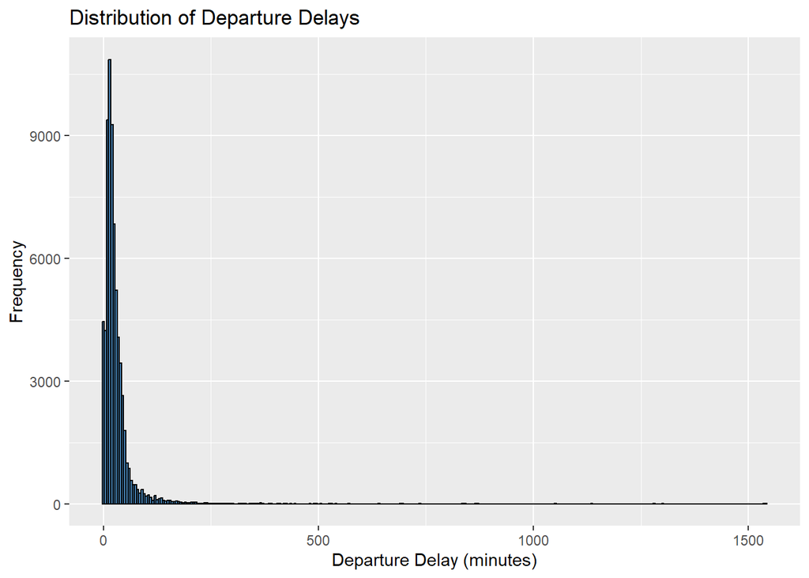

```r
# Distribution of departure delay
ggplot(flight_data, aes(x = departure.delay)) +
  geom_histogram(binwidth = 5, fill = "steelblue", color = "black") +
  labs(title = "Distribution of Departure Delays", x = "Departure Delay (minutes)", y = "Frequency")
```

The distribution is highly skewed to the right, with the majority of flights having low delay times. This indicates that most flights have relatively short delays. The tallest bars near zero on the x-axis suggest that the most frequent delay times are clustered around zero. This implies that many flights either depart on time or with minimal delay. The presence of a long tail extending to the right indicates that while most delays are short, there are some flights with significantly longer delays (reaching up to over 1500 minutes). These extreme delays are relatively rare but contribute to the overall distribution.

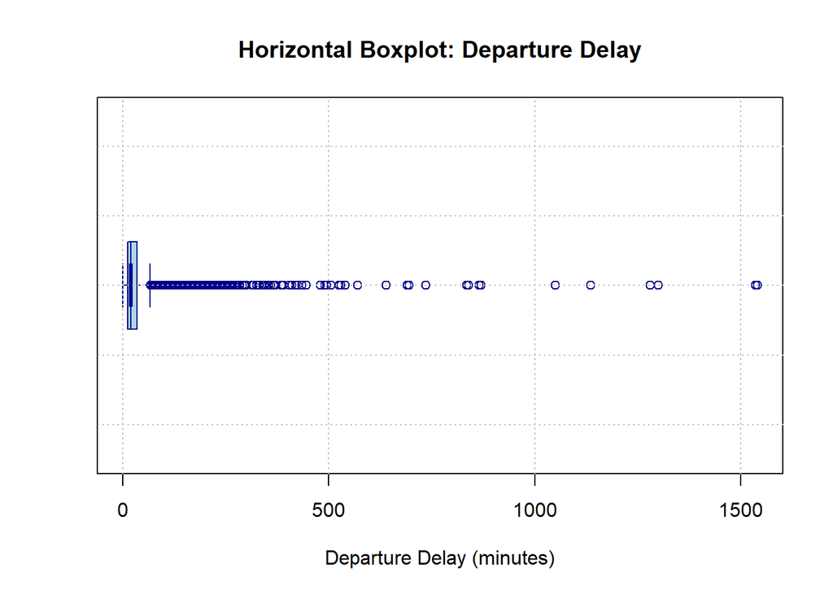

```r
# Boxplot for departure delay
boxplot(
  flight_data$departure.delay,
  horizontal = TRUE,
  main = "Horizontal Boxplot: Departure Delay",
  xlab = "Departure Delay (minutes)",
  col = "lightblue",
  border = "darkblue",
  notch = TRUE,         # Notches for median confidence intervals
  outline = TRUE,       # Show/hide outliers
  boxwex = 0.5          #  Box width
)
grid(nx = NULL, ny = NULL, col = "gray", lty = "dotted") # Grid
```

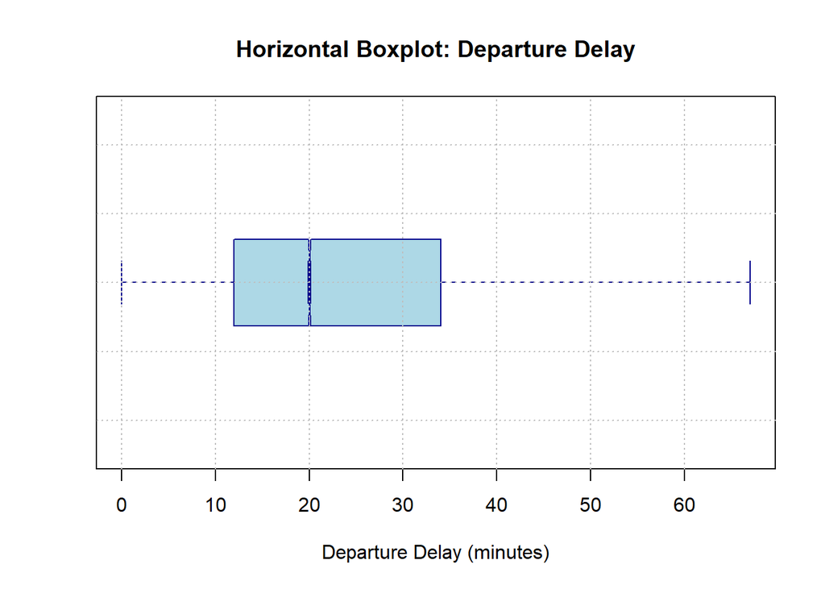

```r
# Boxplot with out outliers
boxplot(
  flight_data$departure.delay,
  horizontal = TRUE,
  main = "Horizontal Boxplot: Departure Delay",
  xlab = "Departure Delay (minutes)",
  col = "lightblue",
  border = "darkblue",
  notch = TRUE,         # Notches for median confidence intervals
  outline = F,       # Show/hide outliers
  boxwex = 0.5          #  Box width
)
grid(nx = NULL, ny = NULL, col = "gray", lty = "dotted") # Grid
```

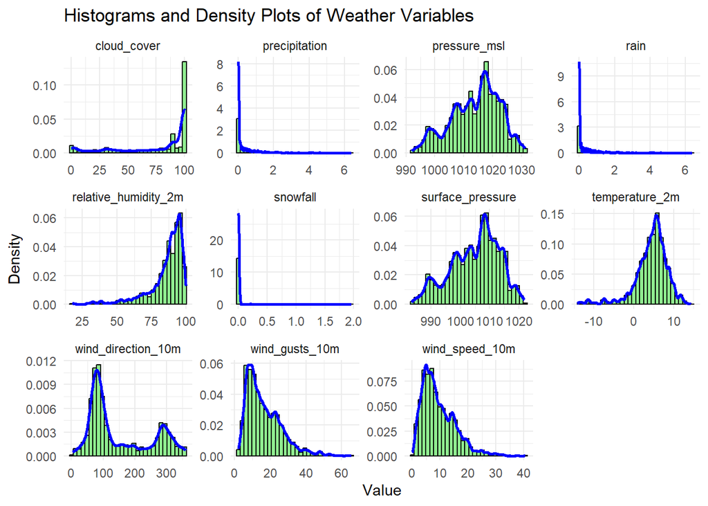

```r
# Histograms for weather conditions
weather_columns <- c("temperature_2m", "precipitation", "rain", "snowfall", "cloud_cover", "wind_speed_10m", "wind_gusts_10m", "pressure_msl", "surface_pressure", "relative_humidity_2m", "wind_direction_10m")

# Reshape data from wide to long format
plot_data <- flight_data %>%
  dplyr::select(all_of(weather_columns)) %>%
  pivot_longer(cols = everything(), names_to = "weather_variable", values_to = "value")

# Create a single histogram plot with density lines for each weather variable using facet_wrap
ggplot(plot_data, aes(x = value)) +
  geom_histogram(aes(y = after_stat(density)), fill = "lightgreen", color = "black", bins = 30) +
  geom_density(color = "blue", size = 1) +
  facet_wrap(~ weather_variable, scales = "free") +
  labs(title = "Histograms and Density Plots of Weather Variables",
       x = "Value",
       y = "Density") +
  theme_minimal()
```

According to the distribution of weather conditions we can identify that precipitation, rain, wind_speed_10m, wind_gusts_10m are skewed to the right while relative_humidity_2m, and cloud_cover are skewed to the left. Also, Bimodal distribution present in wind_direction_10m weather condition while other weather conditions pressure_msl, surface_pressure, has multimodal distribution. Only temperature_2m present normal distribution.

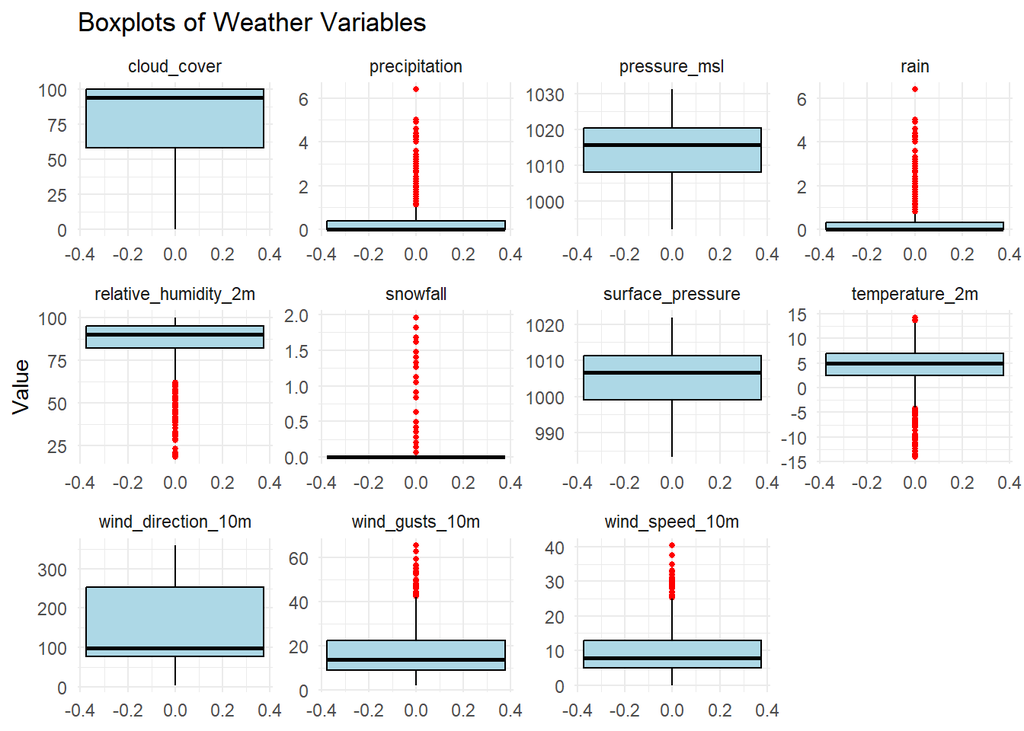

```r
# Create a single boxplot plot for each weather variable using facet_wrap
ggplot(plot_data, aes(y = value)) +
  geom_boxplot(fill = "lightblue", color = "black", outlier.color = "red", outlier.size = 1) +
  facet_wrap(~ weather_variable, scales = "free") +
  labs(title = "Boxplots of Weather Variables",
       x = NULL,  # No x-axis label as the categories are faceted
       y = "Value") +
  theme_minimal()
```

The pressure_msl and surface_pressure have narrow spreads, indicating low variability. Variable wind_direction_10m have wider spreads, showing higher variability.

Many variables, such as precipitation, snowfall, rain, wind_gusts_10m, and temperature_2m, show significant outliers beyond the whiskers. These outliers could represent extreme weather conditions.

Variables with high concentrations of outliers (precipitation and rain) might represent rare but impactful weather events. Further consistently low values for variables such as rain or snowfall suggest that most observations involve dry conditions with occasional heavy rain or snow.

**Distribution plot of Numerical variables raw data vs standardized data**

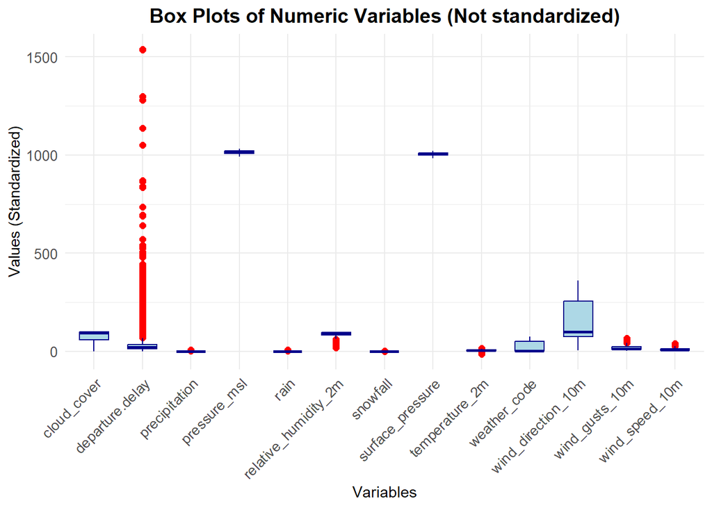

```r
numeric_df <- df[sapply(df, is.numeric)]

# Add row IDs and reshape into tidy format
tidy_data <- numeric_df %>%
  pivot_longer(cols = everything(), names_to = "Variable", values_to = "Value")

# Create box plots for each variable
ggplot(tidy_data, aes(x = Variable, y = Value)) +
  geom_boxplot(fill = "lightblue", color = "darkblue", outlier.color = "red", outlier.size = 2, width = 0.6) +  # Box plot
  theme_minimal() +
  labs(
    title = "Box Plots of Numeric Variables (Not standardized)",
    x = "Variables",
    y = "Values (Standardized)") + theme(
    axis.text.x = element_text(angle = 45, hjust = 1),  # Rotate x-axis labels for readability
    axis.text = element_text(size = 10),
    plot.title = element_text(size = 14, face = "bold", hjust = 0.5)
  )
```

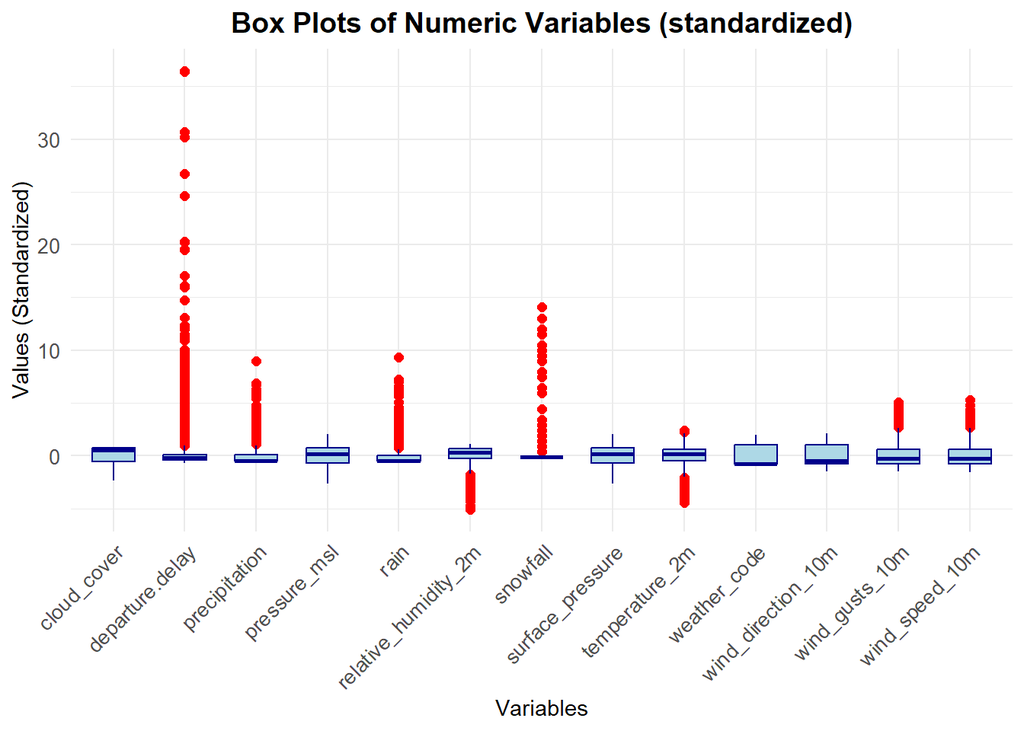

```r
# Standardize the dataset (center and scale)
numeric_df_scaled <- as.data.frame(scale(numeric_df))  # Standardized data

# Add row IDs and reshape into tidy format
tidy_data <- numeric_df_scaled %>%
  pivot_longer(cols = everything(), names_to = "Variable", values_to = "Value")

# Create box plots for each variable
ggplot(tidy_data, aes(x = Variable, y = Value)) +
  geom_boxplot(fill = "lightblue", color = "darkblue", outlier.color = "red", outlier.size = 2, width = 0.6) +  # Box plot
  theme_minimal() +
  labs(
    title = "Box Plots of Numeric Variables (standardized)",
    x = "Variables",
    y = "Values (Standardized)"
  ) +
  theme(
    axis.text.x = element_text(angle = 45, hjust = 1),  # Rotate x-axis labels for readability
    axis.text = element_text(size = 10),
    plot.title = element_text(size = 14, face = "bold", hjust = 0.5)
  )
```

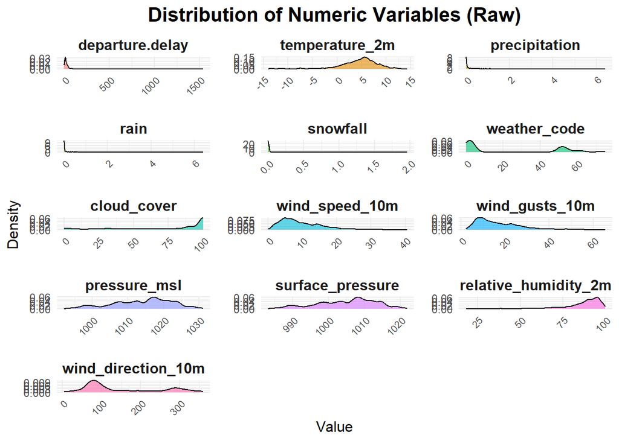

```r
# Subset numeric variables
numeric_data <- df[, sapply(df, is.numeric)]
numeric_sd <- scale(numeric_data)  # Standardize numeric data

# Convert data to long format for plotting
numeric_long <- melt(numeric_data, variable.name = "variable", value.name = "value")
numeric_long_sd <- melt(as.data.frame(numeric_sd), variable.name = "variable", value.name = "value")
# Function to plot distributions
plot_distributions <- function(data, title) {
  ggplot(data, aes(x = value, fill = variable)) +
    geom_density(alpha = 0.6, show.legend = FALSE) +  # Disable legend for better clarity
    facet_wrap(~variable, scales = "free", ncol = 3) +  # Increase columns for better spacing
    theme_minimal() +
    labs(
      title = title,
      x = "Value",
      y = "Density"
    ) +
    theme(
      strip.text = element_text(size = 12, face = "bold"),  # Larger and bold facet labels
      plot.title = element_text(hjust = 0.5, size = 16, face = "bold"),  # Center and style the title
      axis.text.x = element_text(size = 8, angle = 45, hjust = 1),  # Rotate x-axis labels
      axis.text.y = element_text(size = 9),  # Adjust y-axis label size
      axis.title = element_text(size = 12),  # Larger axis titles for clarity
      panel.spacing = unit(1, "lines")  # Add space between facets
    )
}

# Plot for raw data
plot_distributions(numeric_long, "Distribution of Numeric Variables (Raw)")
```

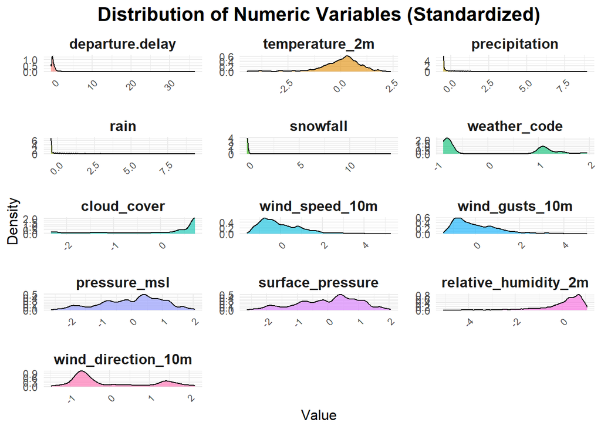

```r
# Plot for standardized data
plot_distributions(numeric_long_sd, "Distribution of Numeric Variables (Standardized)")
```

### Bivariate Analysis: Relationship between flight delay and weather condition

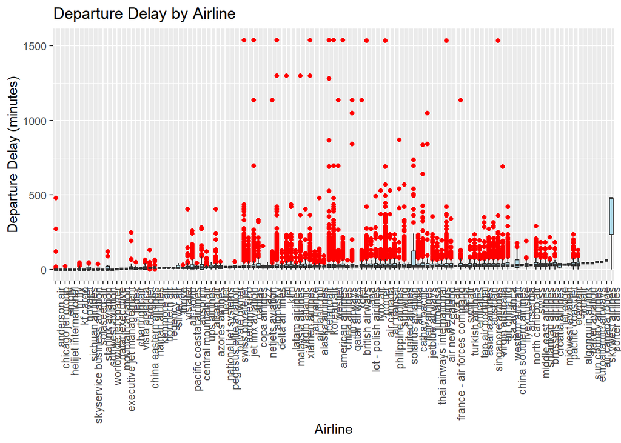

```r
# Boxplot: Delay by Airline
ggplot(flight_data, aes(x = reorder(airline.name, departure.delay, FUN = median), y = departure.delay)) +
  geom_boxplot(outlier.colour = "red", fill = "lightblue") +
  theme(axis.text.x = element_text(angle = 90, hjust = 1)) +
  labs(title = "Departure Delay by Airline", x = "Airline", y = "Departure Delay (minutes)")
```

We can’t find any relationship between flight delays and airlines. With this graph we can say that certain airlines does not experience flight delays.

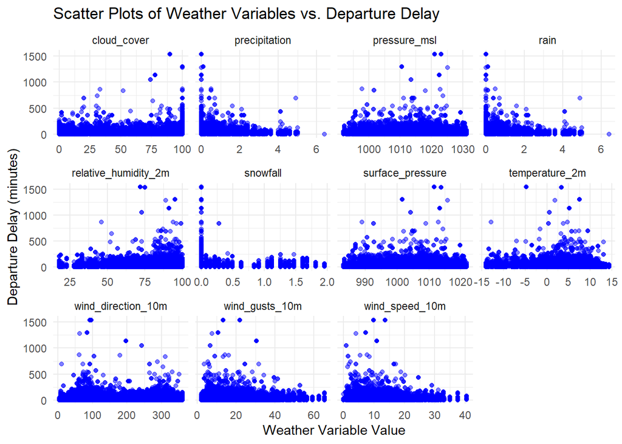

```r
# Select only necessary columns for plotting
plot_data <- flight_data %>%
  dplyr::select(departure.delay, temperature_2m, precipitation, rain, snowfall, cloud_cover,
         wind_speed_10m, wind_gusts_10m, pressure_msl, surface_pressure, relative_humidity_2m, wind_direction_10m) %>%
  pivot_longer(cols = -departure.delay, names_to = "weather_variable", values_to = "value")

# Create a scatter plot with facet wrapping for each weather variable
ggplot(plot_data, aes(x = value, y = departure.delay)) +
  geom_point(alpha = 0.5, color = "blue") +
  facet_wrap(~ weather_variable, scales = "free_x") +
  labs(title = "Scatter Plots of Weather Variables vs. Departure Delay",
       x = "Weather Variable Value",
       y = "Departure Delay (minutes)") +
  theme_minimal()
```

This plot shows scatter plot for each weather variable against departure delay. There is no noticeable upward or downward trend in any scatter plot, and the points were spread out indicates weak relationship between the weather conditions and departure delay. But we can identify that extreme outliers between all of the weather variables and delay time. Which might due to extreme weather conditions that correspond to unusually long delays, such as high Atmospheric air pressure and surface pressure, relative humidity and wind.

### Time Series Analysis

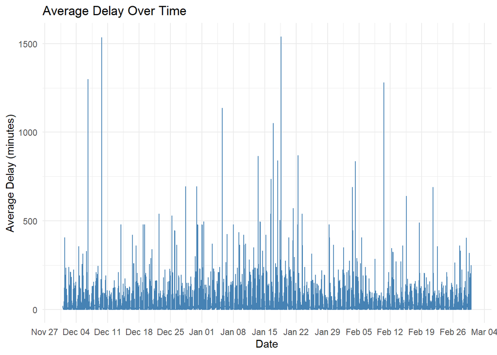

```r
flight_data <- flight_data %>%
  mutate(
    departure.actualTime = as.POSIXct(departure.actualTime),
    departure.scheduledTime = as.POSIXct(departure.scheduledTime)
  )

# Plot delays over time using the existing delay column
ggplot(flight_data, aes(x = departure.scheduledTime, y = departure.delay)) +
  geom_line(color = "steelblue") +
  labs(title = "Average Delay Over Time", x = "Date", y = "Average Delay (minutes)") +
  scale_x_datetime(date_labels = "%b %d", date_breaks = "1 week") +
  theme_minimal()
```

We can identify that two days in Dec 04-11 week, more days in Jan 15-22 week and one day in Feb 12 week have unusually high delays. This can indicate specific times or dates where delays are more common, potentially due to increased air traffic, weather conditions, or other operational factors. Also, there are sudden peaks of delay scould indicate irregular or one-time events that caused delays (e.g., storms, airline strikes, or technical issues). Generally delay is tend to around 0 which means low.

### Correlation Analysis

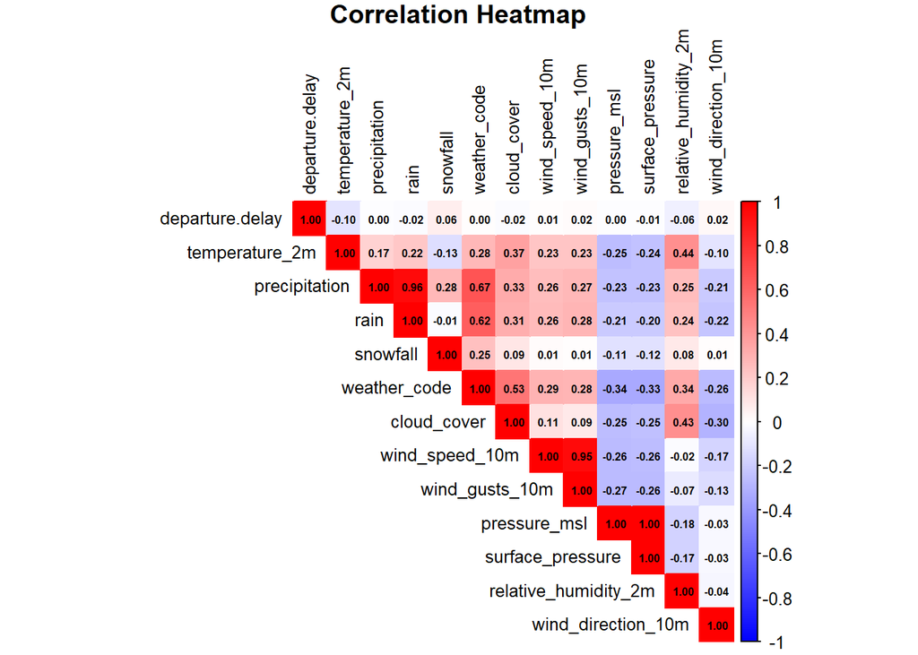

```r
# Compute the correlation matrix for numeric columns
cor_matrix <- cor(df[sapply(df, is.numeric)], use = "complete.obs")
# print(cor_matrix)

# Generate the heatmap with correlation numbers
corrplot(cor_matrix, method = "color", type = "upper",
         col = colorRampPalette(c("blue", "white", "red"))(200),
         tl.col = "black", tl.cex = 0.8,
         addCoef.col = "black", # Correlation numbers in black
         number.cex = 0.5, # Size of numbers
         title = "Correlation Heatmap",
         mar = c(0, 0, 1, 0))
```

No, strong correlation between weather conditions and departure delay.

There are strong correlation between precipitation and rain (0.96), wind_speed_10m and wind_gust_10m (0.95), pressure_msl and surface_pressure (1).

# PROPOSAL 1: PCA to Predict Flight Delay Severity Categories

## Apply PCA on combined flight and weather data to reduce it to key principal components.

**1. Standardize the data**

```r
# Select only the numerical columns
numerical_data <- flight_data[, c('departure.delay', 'temperature_2m', 'precipitation', 'rain', 'snowfall', 'cloud_cover',
                                  'wind_speed_10m', 'wind_gusts_10m', 'pressure_msl', 'surface_pressure', 'relative_humidity_2m',
                                  'wind_direction_10m')]

# Standardize the data (important for PCA)
numerical_data_scaled <- scale(numerical_data)
```

**2. Apply PCA**

```r
# Perform PCA
pca_result <- prcomp(numerical_data_scaled, center = TRUE, scale. = TRUE)

# View the summary of the PCA to understand the explained variance
summary(pca_result)
```

```
## Importance of components:
##                           PC1    PC2    PC3    PC4     PC5     PC6    PC7
## Standard deviation     1.8634 1.3205 1.2799 1.1500 0.99788 0.96287 0.9506
## Proportion of Variance 0.2894 0.1453 0.1365 0.1102 0.08298 0.07726 0.0753
## Cumulative Proportion  0.2894 0.4347 0.5712 0.6814 0.76436 0.84162 0.9169
##                            PC8     PC9    PC10    PC11      PC12
## Standard deviation     0.70927 0.67249 0.20394 0.00242 4.452e-15
## Proportion of Variance 0.04192 0.03769 0.00347 0.00000 0.000e+00
## Cumulative Proportion  0.95885 0.99653 1.00000 1.00000 1.000e+00
```

```r
# View the loadings (contributions of each variable to the principal components)
pca_result$rotation
```

```
##                              PC1         PC2           PC3        PC4
## departure.delay       0.01708417  0.08782201  0.0009854061  0.3009166
## temperature_2m       -0.27687196 -0.15998654  0.0866862825 -0.5090495
## precipitation        -0.38518082 -0.21477078 -0.2981095838  0.3779891
## rain                 -0.37647791 -0.20159885 -0.3307179779  0.2292729
## snowfall             -0.08053064 -0.07236319  0.0675410040  0.5417221
## cloud_cover          -0.29708377 -0.34752906  0.0224597269 -0.1646441
## wind_speed_10m       -0.32895460  0.49020479 -0.2291135692 -0.1581784
## wind_gusts_10m       -0.32657391  0.50895007 -0.2321536238 -0.1330610
## pressure_msl          0.35711080 -0.14148488 -0.5244297576 -0.1113095
## surface_pressure      0.35397857 -0.14483000 -0.5250234671 -0.1202265
## relative_humidity_2m -0.22048424 -0.44746468  0.1402419866 -0.2216314
## wind_direction_10m    0.14799431  0.11558931  0.3353240624  0.1249603
##                              PC5         PC6         PC7          PC8
## departure.delay       0.69246438 -0.64132825  0.06468742  0.078547202
## temperature_2m        0.05489428 -0.10608191  0.24974003  0.527636642
## precipitation        -0.23423134 -0.10190799  0.04192181  0.063479517
## rain                 -0.32647492 -0.28905764 -0.07023880  0.003127603
## snowfall              0.27297723  0.60404163  0.37586025  0.207748376
## cloud_cover           0.33470910  0.13842847 -0.10788999 -0.712692869
## wind_speed_10m        0.09838317  0.09895426  0.18505408 -0.111510818
## wind_gusts_10m        0.06238919  0.06411979  0.18765326 -0.093725251
## pressure_msl          0.06161244  0.02197019  0.23249914 -0.050753070
## surface_pressure      0.06285148  0.02036046  0.23771171 -0.042128986
## relative_humidity_2m  0.11578158 -0.02116551  0.39463024  0.021068486
## wind_direction_10m   -0.36709579 -0.29022043  0.66188282 -0.366450918
##                              PC9          PC10          PC11          PC12
## departure.delay       0.01527506 -0.0068799316  8.646109e-06 -2.260769e-15
## temperature_2m        0.52428516 -0.0323918701  1.178381e-02 -2.628237e-15
## precipitation         0.06629725 -0.0177900848 -2.268469e-05 -7.057023e-01
## rain                  0.02183040 -0.0183671577 -5.098912e-05  6.780741e-01
## snowfall              0.15569360 -0.0004878165  9.037695e-05  2.054259e-01
## cloud_cover           0.33548341  0.0062898977  1.283131e-05 -1.699425e-16
## wind_speed_10m       -0.14908691 -0.6968478298 -1.335674e-04  1.013105e-16
## wind_gusts_10m       -0.05255394  0.7127095747  5.524594e-05 -2.980176e-16
## pressure_msl          0.04652020  0.0011779434  7.084924e-01  3.869442e-16
## surface_pressure      0.05543046  0.0008379722 -7.056200e-01 -1.918650e-16
## relative_humidity_2m -0.71318992  0.0608573808  8.579803e-05  1.003234e-16
## wind_direction_10m    0.21062973 -0.0308584918  1.826222e-05 -1.357284e-16
```

*Eigen values*

```r
eval_life <- (pca_result$sdev)^2 # Eigenvalues (variance explained by each PC)
eval_life
```

```
##  [1] 3.472351e+00 1.743684e+00 1.638159e+00 1.322398e+00 9.957673e-01
##  [6] 9.271109e-01 9.036222e-01 5.030682e-01 4.522415e-01 4.159218e-02
## [11] 5.854318e-06 1.981812e-29
```

*Total variation*

```r
TV <- eval_life/sum(eval_life)*100 # Percentage of total variance explained by each PC
TV
```

```
##  [1] 2.893626e+01 1.453070e+01 1.365132e+01 1.101998e+01 8.298061e+00
##  [6] 7.725924e+00 7.530185e+00 4.192235e+00 3.768679e+00 3.466015e-01
## [11] 4.878598e-05 1.651510e-28
```

```r
cumsum(TV) # Cumulative variance explained by PCs
```

```
##  [1]  28.93626  43.46696  57.11829  68.13827  76.43633  84.16225  91.69244
##  [8]  95.88467  99.65335  99.99995 100.00000 100.00000
```

PC1 to PC3 are the most important, as they explain more than half of the total variance (57.12%). PC4 to PC6 add some explanatory value (up to about 84%), but after that, additional components explain a very minimal amount of variance.

So, I would retain only PC1 to PC6 components as they explain more than 80% of the variance.

**3. Visualize the results**

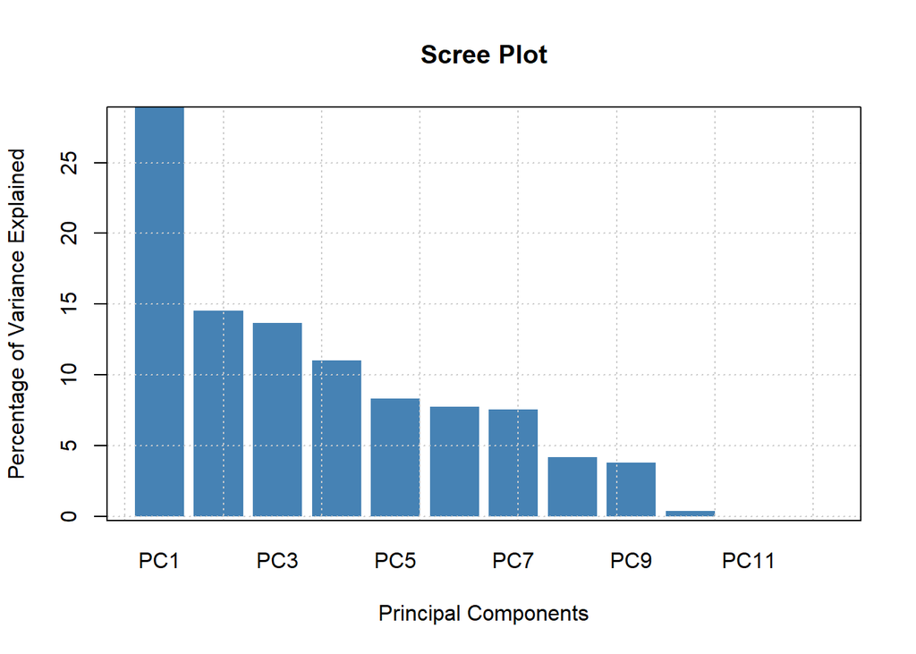

```r
# Scree Plot
eigenvalues <- pca_result$sdev^2  # Eigenvalues
variance_explained <- eigenvalues / sum(eigenvalues) * 100  # Percentage of variance explained

barplot(
  variance_explained,
  names.arg = paste0("PC", 1:length(variance_explained)),
  col = "steelblue",
  main = "Scree Plot",
  xlab = "Principal Components",
  ylab = "Percentage of Variance Explained",
  border = NA
)
grid(nx = NULL, ny = NULL, col = "gray80", lty = "dotted")  # Add gridlines
box()  # Add a border around the plot
```

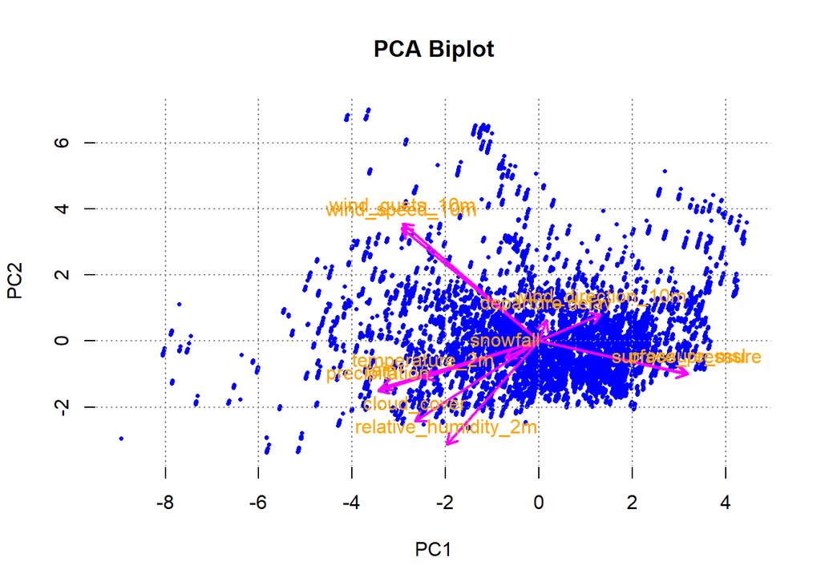

```r
# Set up a black background
par(bg = "white")  # Set the background color of the plot

# Create the PCA plot
plot(pca_result$x[, 1], pca_result$x[, 2],  # Coordinates of PCA scores
     xlab = "PC1", ylab = "PC2",           # Axis labels
     pch = 16,                             # Solid points
     col = "blue",                         # Point color for observations (visible on black)
     main = "PCA Biplot",                  # Title of the plot
     cex = 0.5,                            # Adjust point size for clarity
     col.main = "black",                   # Title color
     col.axis = "black",                   # Axis color
     col.lab = "black")                    # Label color

# Add variable arrows (loadings)
arrows(0, 0, pca_result$rotation[, 1] * max(abs(pca_result$x[, 1])),
       pca_result$rotation[, 2] * max(abs(pca_result$x[, 2])),
       col = "magenta", length = 0.1, lwd = 2)  # Magenta arrows for variables

# Add variable names
text(pca_result$rotation[, 1] * max(abs(pca_result$x[, 1])),
     pca_result$rotation[, 2] * max(abs(pca_result$x[, 2])),
     labels = rownames(pca_result$rotation), col = "orange", cex = 1, pos = 3)

# Add gridlines (adjusted for black background)
grid(nx = NULL, ny = NULL, col = "gray50", lty = "dotted")  # Subtle gray gridlines

# Add a border (adjusted for black background)
box(col = "white")  # White border for contrast
```

*Kaiser Criterion*

```r
eval_life[eval_life>mean(eval_life)] # PCs that explain more than average variance
```

```
## [1] 3.472351 1.743684 1.638159 1.322398
```

The PCs with eigenvalues 3.472351, 1.743684, 1.638159, and 1.322398 explain more variance than an “average” PC.

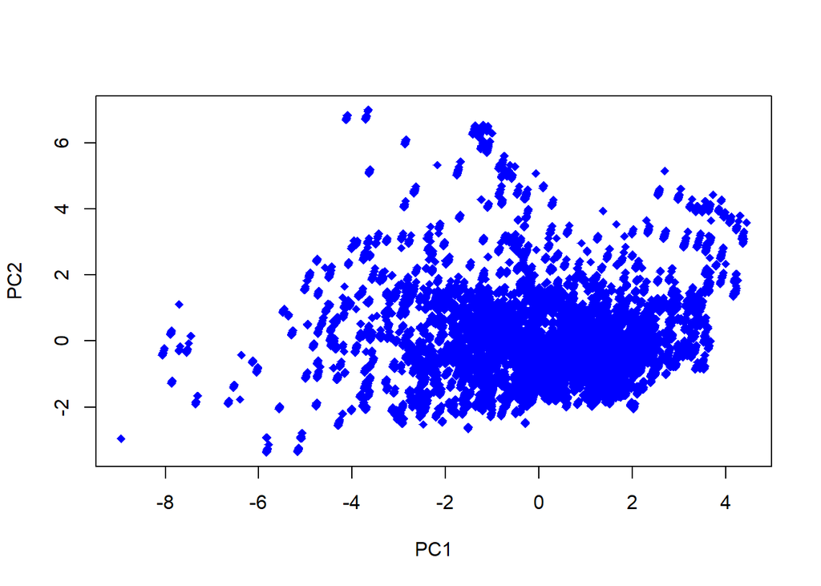

```r
sub_dat <- as.data.frame(pca_result$x[, 1:2])

plot(sub_dat$PC1, sub_dat$PC2, col = "blue", xlab = "PC1", ylab = "PC2", pch =18)  # Plot the first two PCs
```

## Use the reduced components as input for predictive models to classify delay categories.

### Prediction (Multinomial Logistic Regression vs. PCA Regression)

1. Define the Delay Categories

First we create the delay categories based on the departure.delay time.

- No Delay for delays less than or equal to 0 minutes
- Short Delay for delays between 1 and 15 minutes
- Long Delay for delays between 16 and 60 minutes
- Very Long Delay for delays greater than 60 minutes

Note: In this scenario, applying linear regression directly to delay_category may not yield meaningful results because linear regression assumes a continuous numeric response variable, while delay_category is categorical

```r
flight_data1 <- flight_data[, c('departure.delay', 'temperature_2m', 'precipitation', 'rain', 'snowfall', 'cloud_cover', 'wind_speed_10m', 'wind_gusts_10m', 'pressure_msl', 'surface_pressure', 'relative_humidity_2m', 'wind_direction_10m')]
```

```r
# Define delay categories based on departure delay
flight_data1$delay_category <- cut(flight_data1$departure.delay,
                           breaks = c(-Inf, 0, 15, 60, Inf),
                           labels = c("No Delay", "Short Delay", "Long Delay", "Very Long Delay"))
```

```r
# Ensure delay_category is a factor
flight_data1$delay_category <- factor(flight_data1$delay_category)

# Remove the departure.delay column
flight_data1 <- flight_data1[, -1]
```

**Split the Data into Training and Test Sets**

```r
idx <- floor(0.8*nrow(flight_data1)) # Split 80% for training
train_idx <- sample(1:nrow(flight_data1), idx) # Randomly sample training data

train_data <- flight_data1[train_idx, ]  # Training set
test_data <- flight_data1[-train_idx,  ] # Test set
```

**Multinomial logistic regression**

```r
# Fit a multinomial logistic regression model
multinom_model <- multinom(delay_category ~ ., data = train_data)
# Summary of the model
summary(multinom_model)
```

```
## Call:
## multinom(formula = delay_category ~ ., data = train_data)
##
## Coefficients:
##                 (Intercept) temperature_2m precipitation       rain   snowfall
## Short Delay      -10.690259     0.09272281    -0.4722331  0.4341499 -0.6344682
## Long Delay       -15.435692     0.06017423    -0.2200587  0.1956022 -0.2909626
## Very Long Delay    3.166999    -0.01716730     0.0285647 -0.1332238  0.1132520
##                  cloud_cover wind_speed_10m wind_gusts_10m pressure_msl
## Short Delay     -0.003394517    -0.01290387  -0.0007354737   -0.5582178
## Long Delay      -0.002837270    -0.04249631   0.0275866516   -0.1979129
## Very Long Delay  0.002275082    -0.04687957   0.0366218755    0.2932275
##                 surface_pressure relative_humidity_2m wind_direction_10m
## Short Delay            0.5755005          0.003144627      -0.0008567065
## Long Delay             0.2173064          0.001712696      -0.0007338609
## Very Long Delay       -0.2987954         -0.003909256       0.0006296934
##
## Std. Errors:
##                  (Intercept) temperature_2m precipitation        rain
## Short Delay     8.259866e-06    0.005481142   0.007644167 0.007455179
## Long Delay      1.063088e-05    0.005127223   0.007383490 0.006358837
## Very Long Delay 1.528711e-05    0.006269798   0.009926063 0.008510529
##                     snowfall  cloud_cover wind_speed_10m wind_gusts_10m
## Short Delay     0.0001429455 0.0007391352     0.01195791    0.007290717
## Long Delay      0.0008651017 0.0007101496     0.01146451    0.006981739
## Very Long Delay 0.0010055375 0.0009039029     0.01417897    0.008612952
##                 pressure_msl surface_pressure relative_humidity_2m
## Short Delay     9.010486e-05     0.0001389525          0.001795766
## Long Delay      8.135121e-05     0.0001334822          0.001704127
## Very Long Delay 9.479453e-05     0.0001661151          0.002100185
##                 wind_direction_10m
## Short Delay           0.0002126978
## Long Delay            0.0002043414
## Very Long Delay       0.0002575848
##
## Residual Deviance: 112071.1
## AIC: 112137.1
```

The coefficient represent the effect of the predictor variable on the log-odds of being in a particular delay category (“Short Delay,” “Long Delay,” or “Very Long Delay”) compared to the baseline category (“No Delay”).

Positive coefficients indicate that as the predictor variable increases, the likelihood of being in the specific delay category (compared to the baseline) increases while negative coefficients suggest otherwise.

Important factors can be found in the result:

- Temperature_2m: The coefficients are positive for Short Delay and Long Delay, meaning higher temperatures are associated with these delay categories.
- Precipitation, Rain, and Snowfall: These weather factors have both positive and negative impacts on different delay categories.
- Snowfall has a significant negative coefficient for Short Delay, implying it decreases the likelihood of shorter delays but might increase Very Long Delays.
- Wind Gusts (wind_gusts_10m): Shows positive coefficients, suggesting that stronger wind gusts might increase the likelihood of delays.
- Pressure (pressure_msl) and surface_pressure : It’s coefficients vary but seem relatively strong, which could indicate it plays an important role.

**PCA for Regression**

```r
summary(pca_result)
```

```
## Importance of components:
##                           PC1    PC2    PC3    PC4     PC5     PC6    PC7
## Standard deviation     1.8634 1.3205 1.2799 1.1500 0.99788 0.96287 0.9506
## Proportion of Variance 0.2894 0.1453 0.1365 0.1102 0.08298 0.07726 0.0753
## Cumulative Proportion  0.2894 0.4347 0.5712 0.6814 0.76436 0.84162 0.9169
##                            PC8     PC9    PC10    PC11      PC12
## Standard deviation     0.70927 0.67249 0.20394 0.00242 4.452e-15
## Proportion of Variance 0.04192 0.03769 0.00347 0.00000 0.000e+00
## Cumulative Proportion  0.95885 0.99653 1.00000 1.00000 1.000e+00
```

Select Principal Components

```r
# Number of principal components to keep
# Here we select components explaining ~80% of the variance
cumulative_variance <- cumsum(pca_result$sdev^2 / sum(pca_result$sdev^2))
num_components <- which(cumulative_variance >= 0.8)[1]
selected_components <- pca_result$x[, 1:num_components]
```

Combine Selected Principal Components with the Response Variable

```r
pca_data <- data.frame(selected_components, delay_category = flight_data1$delay_category)
```

Split the Data into Training and Test Sets

```r
# Use the same indices for train/test split
train_data_pca <- pca_data[train_idx, ]
test_data_pca <- pca_data[-train_idx, ]
```

Apply Multinomial Logistic Regression Model

```r
multinom_model_pca <- multinom(delay_category ~ ., data = train_data_pca)
summary(multinom_model_pca)
```

```
## Call:
## multinom(formula = delay_category ~ ., data = train_data_pca)
##
## Coefficients:
##                 (Intercept)       PC1      PC2         PC3       PC4      PC5
## Short Delay       12.944168 0.3374534 1.672081  0.03049852  5.624312 13.66508
## Long Delay        20.884153 0.9353934 4.035994 -0.18722319 12.797711 30.82898
## Very Long Delay    6.000193 1.0475455 5.642921 -0.12476751 18.315866 43.60087
##                       PC6
## Short Delay     -12.97145
## Long Delay      -29.69339
## Very Long Delay -40.91157
##
## Std. Errors:
##                 (Intercept)        PC1        PC2        PC3       PC4
## Short Delay       0.2131865 0.01605229 0.03693724 0.02157700 0.1017278
## Long Delay        0.2334520 0.02053655 0.04874739 0.02671827 0.1331417
## Very Long Delay   0.5211776 0.04030784 0.08431534 0.05462700 0.2249218
##                       PC5       PC6
## Short Delay     0.2383456 0.2273863
## Long Delay      0.3112335 0.3004071
## Very Long Delay 0.5162231 0.4682901
##
## Residual Deviance: 27610.86
## AIC: 27652.86
```

Standard errors are small compared to coefficients, suggesting reliable estimates.

*Evaluate the Model on the Test Set*

```r
# For logistic regression, predict the delay category and compare with actual
predictions <- predict(multinom_model_pca, newdata = test_data_pca)
confusion_matrix <- table(predictions, test_data_pca$delay_category)
confusion_matrix
```

```
##
## predictions       No Delay Short Delay Long Delay Very Long Delay
##   No Delay             458         149          9               0
##   Short Delay          319        3503        386               0
##   Long Delay             0         404       7519              55
##   Very Long Delay        0           0         33             959
```

```r
# Sensitivity, Specificity, and Accuracy Calculation
sensitivity <- numeric()
specificity <- numeric()
total_correct <- 0
total_instances <- sum(confusion_matrix)

for (i in 1:nrow(confusion_matrix)) {
  # True Positives (TP)
  TP <- confusion_matrix[i, i]

  # False Negatives (FN) - sum of the current row excluding TP
  FN <- sum(confusion_matrix[i, ]) - TP

  # False Positives (FP) - sum of the current column excluding TP
  FP <- sum(confusion_matrix[, i]) - TP

  # True Negatives (TN) - sum of all elements excluding current row and column
  TN <- total_instances - TP - FN - FP

  # Sensitivity (Recall)
  sensitivity[i] <- TP / (TP + FN)

  # Specificity
  specificity[i] <- TN / (TN + FP)

  # Add correct predictions to total
  total_correct <- total_correct + TP
}

# Accuracy
accuracy <- total_correct / total_instances

# Results
results <- data.frame(
  Class = rownames(confusion_matrix),
  Sensitivity = sensitivity,
  Specificity = specificity
)

list(Accuracy = accuracy, Results_Per_Class = results)
```

```
## $Accuracy
## [1] 0.9017689
##
## $Results_Per_Class
##             Class Sensitivity Specificity
## 1        No Delay   0.7435065   0.9757930
## 2     Short Delay   0.8324620   0.9423117
## 3      Long Delay   0.9424668   0.9264099
## 4 Very Long Delay   0.9667339   0.9957038
```

The confusion matrix reflects imbalances in class-specific predictions. For example, “Short Delay” and “Long Delay” dominate the dataset, which may affect predictions for smaller classes like “No Delay” and “Very Long Delay.

# PROPOSAL 2: Weather Impact Analysis on Delays Using FA

Select weather variables and scale them.

```r
weather_data  <- flight_data[, c('departure.delay', 'temperature_2m', 'precipitation', 'rain', 'snowfall', 'cloud_cover',
                                 'wind_speed_10m', 'wind_gusts_10m', 'pressure_msl', 'surface_pressure', 'relative_humidity_2m',
                                 'wind_direction_10m')]

# Standardize the data
scaled_weather_data <- scale(weather_data)
```

**Covariance and Correlation Analysis**

```r
cov(weather_data)
```

```
##                      departure.delay temperature_2m precipitation          rain
## departure.delay        1715.21689043    -17.7438022   -0.03655799  -0.528298785
## temperature_2m          -17.74380216     17.1862787    0.48556005   0.587915770
## precipitation            -0.03655799      0.4855601    0.45987742   0.422741612
## rain                     -0.52829878      0.5879158    0.42274161   0.424573916
## snowfall                  0.34421856     -0.0716490    0.02599506  -0.001282613
## cloud_cover             -27.01486498     49.6855279    7.22040095   6.624809934
## wind_speed_10m            1.66712911      5.5501080    1.02621493   1.009508632
## wind_gusts_10m            6.78844189      9.2739666    1.81225043   1.794596803
## pressure_msl             -1.48749955     -8.7418855   -1.31588248  -1.128055099
## surface_pressure         -2.05902107     -8.0918098   -1.28820843  -1.098886018
## relative_humidity_2m    -32.03998137     24.2376358    2.27530779   2.064067408
## wind_direction_10m       88.76181233    -40.8458890  -13.95038555 -14.137594394
##                          snowfall  cloud_cover wind_speed_10m wind_gusts_10m
## departure.delay       0.344218558  -27.0148650     1.66712911     6.78844189
## temperature_2m       -0.071649002   49.6855279     5.55010795     9.27396657
## precipitation         0.025995065    7.2204010     1.02621493     1.81225043
## rain                 -0.001282613    6.6248099     1.00950863     1.79459680
## snowfall              0.019094375    0.4169137     0.01169441     0.01235754
## cloud_cover           0.416913713 1064.8329747    21.74737341    27.14968939
## wind_speed_10m        0.011694411   21.7473734    34.82983745    54.85288980
## wind_gusts_10m        0.012357535   27.1496894    54.85288980    94.81052156
## pressure_msl         -0.131479166  -68.7020659   -12.93628904   -21.62700487
## surface_pressure     -0.132525685  -66.4228566   -12.64203681   -21.13480379
## relative_humidity_2m  0.147868264  188.1308052    -1.28471403    -9.16486259
## wind_direction_10m    0.131046191 -954.8179878   -96.59274536  -125.30198863
##                      pressure_msl surface_pressure relative_humidity_2m
## departure.delay        -1.4874995       -2.0590211          -32.0399814
## temperature_2m         -8.7418855       -8.0918098           24.2376358
## precipitation          -1.3158825       -1.2882084            2.2753078
## rain                   -1.1280551       -1.0988860            2.0640674
## snowfall               -0.1314792       -0.1325257            0.1478683
## cloud_cover           -68.7020659      -66.4228566          188.1308052
## wind_speed_10m        -12.9362890      -12.6420368           -1.2847140
## wind_gusts_10m        -21.6270049      -21.1348038           -9.1648626
## pressure_msl           69.9287210       69.0072592          -19.6579296
## surface_pressure       69.0072592       68.1165218          -18.6625852
## relative_humidity_2m  -19.6579296      -18.6625852          176.7309300
## wind_direction_10m    -22.1933498      -23.3011284          -46.3836905
##                      wind_direction_10m
## departure.delay              88.7618123
## temperature_2m              -40.8458890
## precipitation               -13.9503855
## rain                        -14.1375944
## snowfall                      0.1310462
## cloud_cover                -954.8179878
## wind_speed_10m              -96.5927454
## wind_gusts_10m             -125.3019886
## pressure_msl                -22.1933498
## surface_pressure            -23.3011284
## relative_humidity_2m        -46.3836905
## wind_direction_10m         9616.9720394
```

```r
cor(weather_data)
```

```
##                      departure.delay temperature_2m precipitation        rain
## departure.delay          1.000000000     -0.1033466  -0.001301672 -0.01957688
## temperature_2m          -0.103346611      1.0000000   0.172715368  0.21764442
## precipitation           -0.001301672      0.1727154   1.000000000  0.95670336
## rain                    -0.019576878      0.2176444   0.956703365  1.00000000
## snowfall                 0.060148117     -0.1250738   0.277406826 -0.01424513
## cloud_cover             -0.019989528      0.3672808   0.326286816  0.31157028
## wind_speed_10m           0.006820779      0.2268479   0.256413900  0.26251714
## wind_gusts_10m           0.016833806      0.2297451   0.274453580  0.28285377
## pressure_msl            -0.004295063     -0.2521659  -0.232042892 -0.20702646
## surface_pressure        -0.006023862     -0.2364986  -0.230164776 -0.20433829
## relative_humidity_2m    -0.058193764      0.4397877   0.252384587  0.23828184
## wind_direction_10m       0.021854831     -0.1004704  -0.209771262 -0.22124817
##                          snowfall cloud_cover wind_speed_10m wind_gusts_10m
## departure.delay       0.060148117 -0.01998953    0.006820779    0.016833806
## temperature_2m       -0.125073845  0.36728081    0.226847910    0.229745140
## precipitation         0.277406826  0.32628682    0.256413900    0.274453580
## rain                 -0.014245129  0.31157028    0.262517136    0.282853767
## snowfall              1.000000000  0.09245975    0.014340025    0.009184402
## cloud_cover           0.092459750  1.00000000    0.112925063    0.085446810
## wind_speed_10m        0.014340025  0.11292506    1.000000000    0.954543052
## wind_gusts_10m        0.009184402  0.08544681    0.954543052    1.000000000
## pressure_msl         -0.113782750 -0.25176842   -0.262123642   -0.265607490
## surface_pressure     -0.116204007 -0.24663265   -0.259546451   -0.262992716
## relative_humidity_2m  0.080494456  0.43367350   -0.016374742   -0.070801329
## wind_direction_10m    0.009670580 -0.29837379   -0.166897415   -0.131223168
##                      pressure_msl surface_pressure relative_humidity_2m
## departure.delay      -0.004295063     -0.006023862          -0.05819376
## temperature_2m       -0.252165923     -0.236498564           0.43978767
## precipitation        -0.232042892     -0.230164776           0.25238459
## rain                 -0.207026464     -0.204338293           0.23828184
## snowfall             -0.113782750     -0.116204007           0.08049446
## cloud_cover          -0.251768422     -0.246632651           0.43367350
## wind_speed_10m       -0.262123642     -0.259546451          -0.01637474
## wind_gusts_10m       -0.265607490     -0.262992716          -0.07080133
## pressure_msl          1.000000000      0.999863590          -0.17682909
## surface_pressure      0.999863590      1.000000000          -0.17009412
## relative_humidity_2m -0.176829086     -0.170094116           1.00000000
## wind_direction_10m   -0.027062997     -0.028789329          -0.03557868
##                      wind_direction_10m
## departure.delay              0.02185483
## temperature_2m              -0.10047043
## precipitation               -0.20977126
## rain                        -0.22124817
## snowfall                     0.00967058
## cloud_cover                 -0.29837379
## wind_speed_10m              -0.16689741
## wind_gusts_10m              -0.13122317
## pressure_msl                -0.02706300
## surface_pressure            -0.02878933
## relative_humidity_2m        -0.03557868
## wind_direction_10m           1.00000000
```

**Correlation adequacy Bartlett’s test**

```r
correlations = cor(weather_data)
cortest.bartlett(correlations, n = nrow(weather_data))
```

```
## $chisq
## [1] 3393381
##
## $p.value
## [1] 0
##
## $df
## [1] 66
```

Interpretation: A significant p-value (< 0.05) indicates that the variables are correlated and suitable for factor analysis.

**Sampling adequacy KMO test**

```r
KMO(correlations)
```

```
## Error in solve.default(r) :
##   system is computationally singular: reciprocal condition number = 1.49753e-16
```

```
## matrix is not invertible, image not found
```

```
## Kaiser-Meyer-Olkin factor adequacy
## Call: KMO(r = correlations)
## Overall MSA =  0.5
## MSA for each item =
##      departure.delay       temperature_2m        precipitation
##                  0.5                  0.5                  0.5
##                 rain             snowfall          cloud_cover
##                  0.5                  0.5                  0.5
##       wind_speed_10m       wind_gusts_10m         pressure_msl
##                  0.5                  0.5                  0.5
##     surface_pressure relative_humidity_2m   wind_direction_10m
##                  0.5                  0.5                  0.5
```

The Kaiser-Meyer-Olkin (KMO) test result suggests low sampling adequacy for the weather variables (with a KMO value of 0.5), which indicates that these variables may not be highly suitable for factor analysis (FA).

**Steps to Improve Factor Analysis Suitability**

Check for Highly Correlated Variables and Remove Redundancies

```r
# Display correlation matrix to identify highly correlated pairs
print(correlations)
```

```
##                      departure.delay temperature_2m precipitation        rain
## departure.delay          1.000000000     -0.1033466  -0.001301672 -0.01957688
## temperature_2m          -0.103346611      1.0000000   0.172715368  0.21764442
## precipitation           -0.001301672      0.1727154   1.000000000  0.95670336
## rain                    -0.019576878      0.2176444   0.956703365  1.00000000
## snowfall                 0.060148117     -0.1250738   0.277406826 -0.01424513
## cloud_cover             -0.019989528      0.3672808   0.326286816  0.31157028
## wind_speed_10m           0.006820779      0.2268479   0.256413900  0.26251714
## wind_gusts_10m           0.016833806      0.2297451   0.274453580  0.28285377
## pressure_msl            -0.004295063     -0.2521659  -0.232042892 -0.20702646
## surface_pressure        -0.006023862     -0.2364986  -0.230164776 -0.20433829
## relative_humidity_2m    -0.058193764      0.4397877   0.252384587  0.23828184
## wind_direction_10m       0.021854831     -0.1004704  -0.209771262 -0.22124817
##                          snowfall cloud_cover wind_speed_10m wind_gusts_10m
## departure.delay       0.060148117 -0.01998953    0.006820779    0.016833806
## temperature_2m       -0.125073845  0.36728081    0.226847910    0.229745140
## precipitation         0.277406826  0.32628682    0.256413900    0.274453580
## rain                 -0.014245129  0.31157028    0.262517136    0.282853767
## snowfall              1.000000000  0.09245975    0.014340025    0.009184402
## cloud_cover           0.092459750  1.00000000    0.112925063    0.085446810
## wind_speed_10m        0.014340025  0.11292506    1.000000000    0.954543052
## wind_gusts_10m        0.009184402  0.08544681    0.954543052    1.000000000
## pressure_msl         -0.113782750 -0.25176842   -0.262123642   -0.265607490
## surface_pressure     -0.116204007 -0.24663265   -0.259546451   -0.262992716
## relative_humidity_2m  0.080494456  0.43367350   -0.016374742   -0.070801329
## wind_direction_10m    0.009670580 -0.29837379   -0.166897415   -0.131223168
##                      pressure_msl surface_pressure relative_humidity_2m
## departure.delay      -0.004295063     -0.006023862          -0.05819376
## temperature_2m       -0.252165923     -0.236498564           0.43978767
## precipitation        -0.232042892     -0.230164776           0.25238459
## rain                 -0.207026464     -0.204338293           0.23828184
## snowfall             -0.113782750     -0.116204007           0.08049446
## cloud_cover          -0.251768422     -0.246632651           0.43367350
## wind_speed_10m       -0.262123642     -0.259546451          -0.01637474
## wind_gusts_10m       -0.265607490     -0.262992716          -0.07080133
## pressure_msl          1.000000000      0.999863590          -0.17682909
## surface_pressure      0.999863590      1.000000000          -0.17009412
## relative_humidity_2m -0.176829086     -0.170094116           1.00000000
## wind_direction_10m   -0.027062997     -0.028789329          -0.03557868
##                      wind_direction_10m
## departure.delay              0.02185483
## temperature_2m              -0.10047043
## precipitation               -0.20977126
## rain                        -0.22124817
## snowfall                     0.00967058
## cloud_cover                 -0.29837379
## wind_speed_10m              -0.16689741
## wind_gusts_10m              -0.13122317
## pressure_msl                -0.02706300
## surface_pressure            -0.02878933
## relative_humidity_2m        -0.03557868
## wind_direction_10m           1.00000000
```

```r
# Remove one variable from each highly correlated pair
weather_data_reduced <- weather_data[, -which(colnames(weather_data) %in% c('precipitation', 'wind_gusts_10m', 'pressure_msl'))]
```

```r
# Recompute correlations with the reduced dataset
correlations_reduced <- cor(weather_data_reduced)

# Run the KMO test on the reduced dataset
KMO(correlations_reduced)
```

```
## Kaiser-Meyer-Olkin factor adequacy
## Call: KMO(r = correlations_reduced)
## Overall MSA =  0.65
## MSA for each item =
##      departure.delay       temperature_2m                 rain
##                 0.63                 0.66                 0.76
##             snowfall          cloud_cover       wind_speed_10m
##                 0.35                 0.70                 0.57
##     surface_pressure relative_humidity_2m   wind_direction_10m
##                 0.68                 0.63                 0.54
```

KMO test measures the adequacy of sampling for factor analysis, with values > 0.6 indicating that factor analysis is appropriate.

**Determining the Number of Factors**

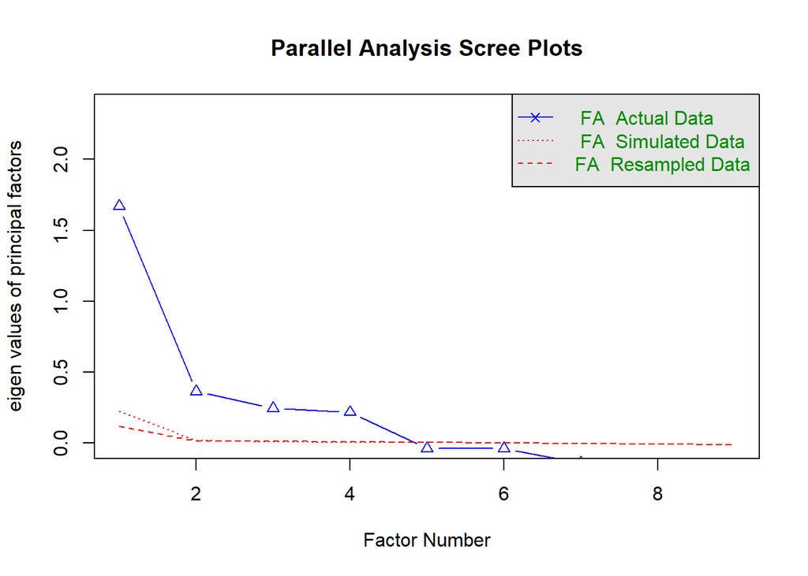

```
## Parallel analysis suggests that the number of factors =  4  and the number of components =  NA
```

```r
# fm: What factor method to use: minres, ml, uls, wls, gls, pa
# fa: show the eigen values for a principal components
# fa: you can have fa or pc, or both

nofactors = fa.parallel(weather_data_reduced, fm="ml", fa="fa")
```

```r
nofactors$fa.values # eigen values
```

```
## [1]  1.67174371  0.36199757  0.24260590  0.21547684 -0.03965657 -0.04085632
## [7] -0.14365117 -0.28586423 -0.31398142
```

**Perform Factor Analysis on Reduced Weather Data**

```r
# Conduct Factor Analysis with 4 factors
fa_result <- fa(correlations_reduced, nfactors = 4, rotate = "varimax")

# Display factor loadings to understand the contribution of each variable to the factors
print(fa_result$loadings)
```

```
##
## Loadings:
##                      MR1    MR3    MR2    MR4
## departure.delay                           -0.159
## temperature_2m        0.552  0.313         0.475
## rain                  0.287  0.318 -0.234
## snowfall              0.116               -0.409
## cloud_cover           0.634  0.155 -0.314
## wind_speed_10m               0.711 -0.142
## surface_pressure     -0.288 -0.425         0.148
## relative_humidity_2m  0.716
## wind_direction_10m                  0.767
##
##                  MR1   MR3   MR2   MR4
## SS loadings    1.408 0.916 0.770 0.454
## Proportion Var 0.156 0.102 0.086 0.050
## Cumulative Var 0.156 0.258 0.344 0.394
```

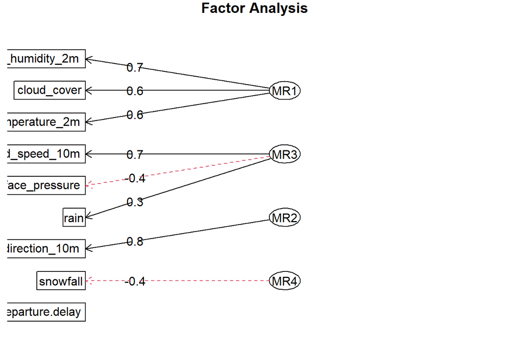

```r
fa.diagram(fa_result)
```

- Factor MR1 (Primary Weather Factor):

Key Contributors: temperature_2m (0.552), cloud_cover (0.634), and relative_humidity_2m (0.716).

Interpretation: This factor appears to represent temperature and humidity conditions. High loadings on temperature, cloud cover, and humidity suggest that MR1 relates to general atmospheric conditions.

- Factor MR3:

Key Contributors: wind_speed_10m (0.711) and possibly rain (0.318).

Interpretation: MR3 could represent wind-related weather conditions. The presence of wind_speed_10m as a strong contributor indicates this factor may capture the impact of wind on flight delays.

- Factor MR2:

Key Contributors: wind_direction_10m (0.767).

Interpretation: MR2 seems to represent wind direction specifically. High variance in wind direction could impact flight schedules, especially departures and arrivals.

- Factor MR4:

Key Contributors: snowfall (-0.409).

Interpretation: MR4 appears to capture precipitation-specific weather conditions, particularly snowfall, which can directly impact flights due to runway conditions and visibility.

Variance Explanation

MR1 explains 15.6% of the variance, MR3 explains 10.2%, MR2 explains 8.6%, and MR4 explains 5.0%. Together, these factors account for about 39.4% of the variance in the dataset, meaning they provide a moderate summary of the weather data’s variability.

```r
# Perform Factor Analysis with Scores
fa_result <- principal(weather_data, nfactors = 4, rotate = "varimax", scores = TRUE)
```

[output not shown]

```r
print(fa_result)
```

```
## Principal Components Analysis
## Call: principal(r = weather_data, nfactors = 4, rotate = "varimax",
##     scores = TRUE)
## Standardized loadings (pattern matrix) based upon correlation matrix
##                        RC1   RC3   RC2   RC4   h2    u2 com
## departure.delay       0.06 -0.07 -0.01 -0.35 0.13 0.866 1.1
## temperature_2m        0.15 -0.22  0.16  0.75 0.67 0.334 1.4
## precipitation         0.94 -0.14  0.13 -0.09 0.93 0.070 1.1
## rain                  0.88 -0.06  0.20  0.05 0.81 0.188 1.1
## snowfall              0.34 -0.27 -0.19 -0.45 0.43 0.573 3.0
## cloud_cover           0.49 -0.23 -0.08  0.51 0.55 0.446 2.4
## wind_speed_10m        0.16 -0.15  0.93  0.06 0.91 0.086 1.1
## wind_gusts_10m        0.16 -0.15  0.94  0.02 0.93 0.066 1.1
## pressure_msl         -0.08  0.95 -0.16 -0.07 0.94 0.055 1.1
## surface_pressure     -0.08  0.95 -0.16 -0.06 0.94 0.058 1.1
## relative_humidity_2m  0.36 -0.24 -0.28  0.59 0.62 0.385 2.6
## wind_direction_10m   -0.39 -0.24 -0.20 -0.23 0.30 0.696 2.9
##
##                        RC1  RC3  RC2  RC4
## SS loadings           2.38 2.18 2.05 1.58
## Proportion Var        0.20 0.18 0.17 0.13
## Cumulative Var        0.20 0.38 0.55 0.68
## Proportion Explained  0.29 0.27 0.25 0.19
## Cumulative Proportion 0.29 0.56 0.81 1.00
##
## Mean item complexity =  1.7
## Test of the hypothesis that 4 components are sufficient.
##
## The root mean square of the residuals (RMSR) is  0.09
##  with the empirical chi square  72249.36  with prob <  0
##
## Fit based upon off diagonal values = 0.9
```

```r
# Extract factor scores
factor_scores <- fa_result$scores

# Add the factor scores to the original dataset
weather_data_with_factors <- cbind(weather_data, factor_scores)

# Regression Analysis with Factors as Predictors for `departure.delay`
lm_delay_factors <- lm(departure.delay ~ RC1 + RC2 + RC3 + RC4, data = weather_data_with_factors)
summary(lm_delay_factors)
```

```
##
## Call:
## lm(formula = departure.delay ~ RC1 + RC2 + RC3 + RC4, data = weather_data_with_factors)
##
## Residuals:
##     Min      1Q  Median      3Q     Max
## -123.00  -14.95   -4.15    8.02 1362.60
##
## Coefficients:
##              Estimate Std. Error  t value Pr(>|t|)
## (Intercept)  28.67798    0.14674  195.431  < 2e-16 ***
## RC1           2.64930    0.07660   34.587  < 2e-16 ***
## RC2          -0.64512    0.08042   -8.022 1.06e-15 ***
## RC3          -2.40173    0.07949  -30.213  < 2e-16 ***
## RC4         -10.58195    0.10273 -103.012  < 2e-16 ***
## ---
## Signif. codes:  0 '***' 0.001 '**' 0.01 '*' 0.05 '.' 0.1 ' ' 1
##
## Residual standard error: 38.54 on 68963 degrees of freedom
## Multiple R-squared:  0.1342, Adjusted R-squared:  0.1342
## F-statistic:  2673 on 4 and 68963 DF,  p-value: < 2.2e-16
```

The Multiple R-squared of 0.1342 means that the model explains around 13.4% of the variance in departure.delay using these four factors.

Given the Residual Standard Error of 38.54, there remains substantial unexplained variance, which may be due to other factors not captured by the four components or other types of delays (e.g., airline or airport factors).

# Proposal 3 - Perform stepwise regression to identify most important predictors in flight delays

```r
data_clean <- flight_data %>%
  mutate_if(is.character, as.factor) %>%
  dplyr::select(-status, -departure.scheduledTime, -departure.estimatedTime, -departure.actualTime, -airline.name)
```

```r
#full formula
formula <- departure.delay ~ temperature_2m + precipitation + rain + snowfall +
           weather_code + cloud_cover + wind_speed_10m + wind_gusts_10m +
           pressure_msl + surface_pressure + relative_humidity_2m + wind_direction_10m

#full model
full_model <- lm(formula, data = data_clean)
```

```r
#stepwise regression
library(MASS)
stepwise_model <- stepAIC(full_model, direction = "both")
```

```
## Start:  AIC=512485.9
## departure.delay ~ temperature_2m + precipitation + rain + snowfall +
##     weather_code + cloud_cover + wind_speed_10m + wind_gusts_10m +
##     pressure_msl + surface_pressure + relative_humidity_2m +
##     wind_direction_10m
##
##
## Step:  AIC=512485.9
## departure.delay ~ temperature_2m + precipitation + rain + weather_code +
##     cloud_cover + wind_speed_10m + wind_gusts_10m + pressure_msl +
##     surface_pressure + relative_humidity_2m + wind_direction_10m
##
##                        Df Sum of Sq       RSS    AIC
## - surface_pressure      1      1951 116318767 512485
## - pressure_msl          1      1992 116318808 512485
## <none>                              116316816 512486
## - relative_humidity_2m  1     29032 116345848 512501
## - cloud_cover           1     29097 116345912 512501
## - weather_code          1     30330 116347146 512502
## - wind_direction_10m    1     32209 116349025 512503
## - temperature_2m        1     77261 116394077 512530
## - wind_speed_10m        1     88157 116404972 512536
## - precipitation         1    145481 116462297 512570
## - wind_gusts_10m        1    153419 116470235 512575
## - rain                  1    205658 116522474 512606
##
## Step:  AIC=512485.1
## departure.delay ~ temperature_2m + precipitation + rain + weather_code +
##     cloud_cover + wind_speed_10m + wind_gusts_10m + pressure_msl +
##     relative_humidity_2m + wind_direction_10m
##
##                        Df Sum of Sq       RSS    AIC
## <none>                              116318767 512485
## + surface_pressure      1      1951 116316816 512486
## - pressure_msl          1     14665 116333432 512492
## - relative_humidity_2m  1     28602 116347369 512500
## - cloud_cover           1     29347 116348114 512500
## - weather_code          1     29816 116348583 512501
## - wind_direction_10m    1     32268 116351035 512502
## - wind_speed_10m        1     88532 116407299 512536
## - precipitation         1    147193 116465960 512570
## - wind_gusts_10m        1    153621 116472388 512574
## - rain                  1    207847 116526614 512606
## - temperature_2m        1    930400 117249167 513033
```

```r
summary(stepwise_model)
```

```
##
## Call:
## lm(formula = departure.delay ~ temperature_2m + precipitation +
##     rain + weather_code + cloud_cover + wind_speed_10m + wind_gusts_10m +
##     pressure_msl + relative_humidity_2m + wind_direction_10m,
##     data = data_clean)
##
## Residuals:
##     Min      1Q  Median      3Q     Max
##  -55.81  -15.95   -7.40    5.64 1505.55
##
## Coefficients:
##                       Estimate Std. Error t value Pr(>|t|)
## (Intercept)          94.487621  21.380245   4.419 9.91e-06 ***
## temperature_2m       -1.085347   0.046214 -23.485  < 2e-16 ***
## precipitation         8.057681   0.862587   9.341  < 2e-16 ***
## rain                 -9.474899   0.853568 -11.100  < 2e-16 ***
## weather_code          0.038899   0.009252   4.204 2.62e-05 ***
## cloud_cover           0.026188   0.006279   4.171 3.04e-05 ***
## wind_speed_10m       -0.666975   0.092065  -7.245 4.38e-13 ***
## wind_gusts_10m        0.541907   0.056785   9.543  < 2e-16 ***
## pressure_msl         -0.061434   0.020836  -2.948  0.00319 **
## relative_humidity_2m -0.060995   0.014813  -4.118 3.83e-05 ***
## wind_direction_10m    0.007645   0.001748   4.374 1.22e-05 ***
## ---
## Signif. codes:  0 '***' 0.001 '**' 0.01 '*' 0.05 '.' 0.1 ' ' 1
##
## Residual standard error: 41.07 on 68957 degrees of freedom
## Multiple R-squared:  0.01669,    Adjusted R-squared:  0.01655
## F-statistic: 117.1 on 10 and 68957 DF,  p-value: < 2.2e-16
```

The final model after stepwise regression includes 10 predictors.

Only 1.67% of the variation in departure.delay is explained by the predictors. This is very low, indicating a weak model fit.

The low R-squared indicates other factors (e.g., operational delays, human error) likely influence departure.delay.

The recommendation in this case is to use non-linear modeling techniques (e.g., random forests, GAMs) for better predictions if relationships are non-linear.

# Proposal 4 - Correspondance Analysis to identify how categorical variables effects on flight delay category

```r
# Create the CA dataset with respective categories for analysis (Categorization of numerical data)

ca_flight_data <- flight_data %>%
  mutate(
    delay_category = cut(departure.delay,
                         breaks = c(-Inf, 0, 15, 60, Inf),
                         labels = c("No Delay", "Short Delay", "Long Delay", "Very Long Delay")),
    snowfall_category = cut(snowfall,
                            breaks = c(-Inf, 0.01, 0.1, 1, Inf),
                            labels = c("None", "Light", "Moderate", "Heavy")),
    rain_category = cut(rain,
                        breaks = c(-Inf, 0.1, 1, 3, Inf),
                        labels = c("None", "Light", "Moderate", "Heavy")),
    wind_speed_category = cut(wind_speed_10m,
                               breaks = c(-Inf, 5, 15, 30, Inf),
                               labels = c("Calm", "Breezy", "Windy", "Very Windy"))
  )

ca_flight_data <- ca_flight_data %>%
  subset(select = c("delay_category", "snowfall_category", "rain_category", "wind_speed_category"))

head(ca_flight_data)
```

```
##   delay_category snowfall_category rain_category wind_speed_category
## 1    Short Delay              None         Light              Breezy
## 2    Short Delay              None         Light              Breezy
## 3    Short Delay              None         Light              Breezy
## 4    Short Delay              None         Light              Breezy
## 5     Long Delay              None         Light              Breezy
## 6     Long Delay              None         Light              Breezy
```

```
##
##                    None Light Moderate Heavy
##   No Delay         3543    69      111    92
##   Short Delay     20555    24      267    36
##   Long Delay      38200   155      618   258
##   Very Long Delay  4600    50      218   172
```

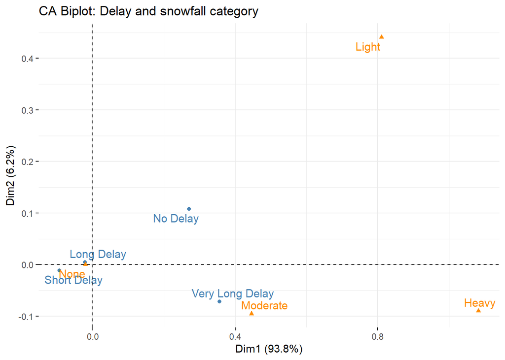

```r
# Function to perform CA and plot for selected variables

perform_CA_plot <- function(ca_flight_data, weather_variable) {

  # Check if the input weather variable is valid
  if (!weather_variable %in% c("snowfall_category", "rain_category", "wind_speed_category")) {
    stop("Invalid weather variable. Choose from 'snowfall_category', 'rain_category', or 'wind_speed_category'.")
  }

  # Creation of the Contingency Table
  ca_contingency_table <- table(ca_flight_data$delay_category, ca_flight_data[[weather_variable]])

  # Print the Contingency Table
  print(ca_contingency_table)

  # Perform Correspondence Analysis (CA)
  ca_result <- CA(ca_contingency_table, graph = FALSE)

  # Plot the CA biplot
  fviz_ca_biplot(ca_result,
                 title = paste("CA Biplot: Delay and", gsub("_", " ", weather_variable)),
                 repel = TRUE,
                 col.row = "steelblue",
                 col.col = "darkorange")
}

# Apply the function for selected variables
perform_CA_plot(ca_flight_data, "snowfall_category")
```

```
##
##                    None Light Moderate Heavy
##   No Delay         2753   693      326    43
##   Short Delay     13998  4730     1894   260
##   Long Delay      27001  8181     3606   443
##   Very Long Delay  3683   929      405    23
```

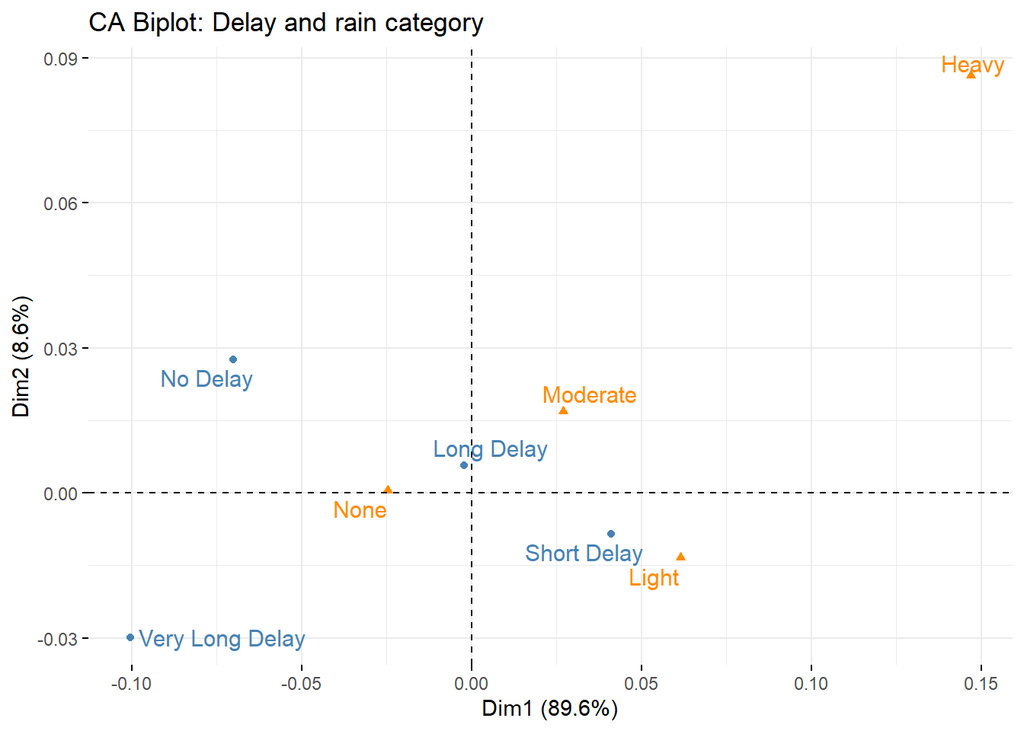

```r
perform_CA_plot(ca_flight_data, "rain_category")
```

```
##
##                    Calm Breezy Windy Very Windy
##   No Delay         1017   2178   590         30
##   Short Delay      5306  12308  3180         88
##   Long Delay      10312  22367  6332        220
##   Very Long Delay  1428   2740   805         67
```

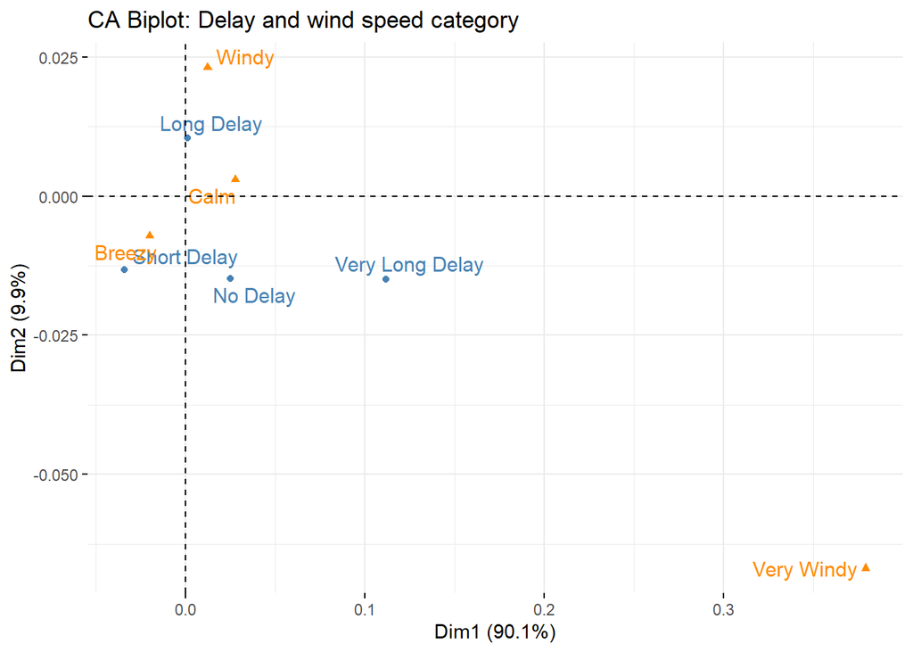

```r
perform_CA_plot(ca_flight_data, "wind_speed_category")
```

Rain: Light rain and Moderate rain have association with delays, although the effect is less pronounced than snowfall, one example is that Long delays are most frequent in Light rain conditions, rather than Moderate or Heavy.

In summary, snowfall has the strongest association with longer delays, followed by wind speed and rain.

# Classification using Random Forest

1. Define the Delay Categories

First we create the delay categories based on the departure.delay time.

- No Delay for delays less than or equal to 0 minutes
- Short Delay for delays between 1 and 15 minutes
- Long Delay for delays between 16 and 60 minutes
- Very Long Delay for delays greater than 60 minutes

```r
flight_data_pca <- flight_data
```

```r
# Define delay categories based on departure delay
flight_data_pca$delay_category <- cut(flight_data_pca$departure.delay,
                           breaks = c(-Inf, 0, 15, 60, Inf),
                           labels = c("No Delay", "Short Delay", "Long Delay", "Very Long Delay"))
```

2. Prepare the Reduced Principal Components

```r
# Select the first few principal components (PC1 to PC6)
pca_data <- as.data.frame(pca_result$x[, 1:6])

# Combine the PCA results with the target variable (delay_category)
model_data <- data.frame(pca_data, delay_category = flight_data_pca$delay_category)
```

3. Split the Data into Training and Test Sets

```r
# Set seed for reproducibility
set.seed(42)

# Split the data (70% for training, 30% for testing)
split <- sample.split(model_data$delay_category, SplitRatio = 0.7)
train_data_rf <- subset(model_data, split == TRUE)
test_data_rf <- subset(model_data, split == FALSE)
```

4. Train a Predictive Model

```r
# Train a Random Forest model
rf_model <- randomForest(delay_category ~ ., data = train_data_rf, importance = TRUE)

# View the model summary
print(rf_model)
```

```
##
## Call:
##  randomForest(formula = delay_category ~ ., data = train_data_rf,      importance = TRUE)
##                Type of random forest: classification
##                      Number of trees: 500
## No. of variables tried at each split: 2
##
##         OOB estimate of  error rate: 1.52%
## Confusion matrix:
##                 No Delay Short Delay Long Delay Very Long Delay class.error
## No Delay            2398         271          1               0 0.101872659
## Short Delay          132       14341        144               0 0.018882124
## Long Delay             0         125      27316              21 0.005316437
## Very Long Delay        0           0         42            3486 0.011904762
```

5. Make Predictions on the Test Set

```r
# Make predictions
predictions <- predict(rf_model, test_data_rf)

# Evaluate model performance
confusion_matrix <- table(Predicted = predictions, Actual = test_data_rf$delay_category)
print(confusion_matrix)
```

```
##                  Actual
## Predicted         No Delay Short Delay Long Delay Very Long Delay
##   No Delay            1028          55          0               0
##   Short Delay          115        6148         62               0
##   Long Delay             2          62      11698              19
##   Very Long Delay        0           0          9            1493
```

6. Evaluate Model Performance

```r
# Calculate accuracy, precision, recall, F1-score
conf_matrix <- confusionMatrix(predictions, test_data_rf$delay_category)
print(conf_matrix)
```

```
## Confusion Matrix and Statistics
##
##                  Reference
## Prediction        No Delay Short Delay Long Delay Very Long Delay
##   No Delay            1028          55          0               0
##   Short Delay          115        6148         62               0
##   Long Delay             2          62      11698              19
##   Very Long Delay        0           0          9            1493
##
## Overall Statistics
##
##                Accuracy : 0.9843
##                  95% CI : (0.9826, 0.986)
##     No Information Rate : 0.5688
##     P-Value [Acc > NIR] : < 2.2e-16
##
##                   Kappa : 0.9728
##
##  Mcnemar's Test P-Value : NA
##
## Statistics by Class:
##
##                      Class: No Delay Class: Short Delay Class: Long Delay
## Sensitivity                  0.89782             0.9813            0.9940
## Specificity                  0.99719             0.9877            0.9907
## Pos Pred Value               0.94922             0.9720            0.9930
## Neg Pred Value               0.99403             0.9919            0.9920
## Prevalence                   0.05534             0.3028            0.5688
## Detection Rate               0.04968             0.2971            0.5654
## Detection Prevalence         0.05234             0.3057            0.5694
## Balanced Accuracy            0.94750             0.9845            0.9923
##                      Class: Very Long Delay
## Sensitivity                         0.98743
## Specificity                         0.99953
## Pos Pred Value                      0.99401
## Neg Pred Value                      0.99901
## Prevalence                          0.07308
## Detection Rate                      0.07216
## Detection Prevalence                0.07259
## Balanced Accuracy                   0.99348
```

- The accuracy is 0.9843 (98.43%), indicating that the model is highly accurate in predicting the delay categories.
- The Kappa value of 0.9728 indicates excellent agreement between the predicted and actual categories beyond chance.

*Sensitivity* measures the ability of the model to correctly identify positive cases for each class. Very high values for all classes, particularly “Long Delay” (99.40%) and “Very Long Delay” (98.74%), indicating strong identification capabilities.

*Specificity* measures the ability to correctly identify negative cases. Values are high for all the classes, suggesting that the model avoids misclassifying other classes as a given class.

Analysis of Performance:

*Strengths:*

- The RF model is highly accurate and consistent, as shown by the high accuracy, Kappa, and class-specific metrics.
- Classes with higher prevalence (“Long Delay” and “Short Delay”) are predicted with great precision and recall.
- Less frequent classes (“No Delay” and “Very Long Delay”) are also predicted with relatively high accuracy, suggesting that the model generalizes well despite class imbalances.

*Potential Limitations:*

- Some misclassifications exist
- Performance may slightly favor more prevalent classes like “Long Delay.”
7. Visualize Feature Importance

```r
# Get feature importance
importance(rf_model)
```

```
##      No Delay Short Delay Long Delay Very Long Delay MeanDecreaseAccuracy
## PC1 110.84110   123.53505   90.83403        55.21162            115.21656
## PC2 122.64794   178.40202  152.27131        80.27865            177.35553
## PC3  81.00066    80.41013   72.58482        53.70176             80.84583
## PC4 132.39857   195.48099  131.87107        79.10540            171.98983
## PC5 360.55169   458.40521  451.24822       240.21411            506.73302
## PC6 399.54441   547.48358  381.93206       170.58676            496.51696
##     MeanDecreaseGini
## PC1         2252.600
## PC2         2681.369
## PC3         1891.160
## PC4         3464.068
## PC5         9186.908
## PC6         8348.386
```

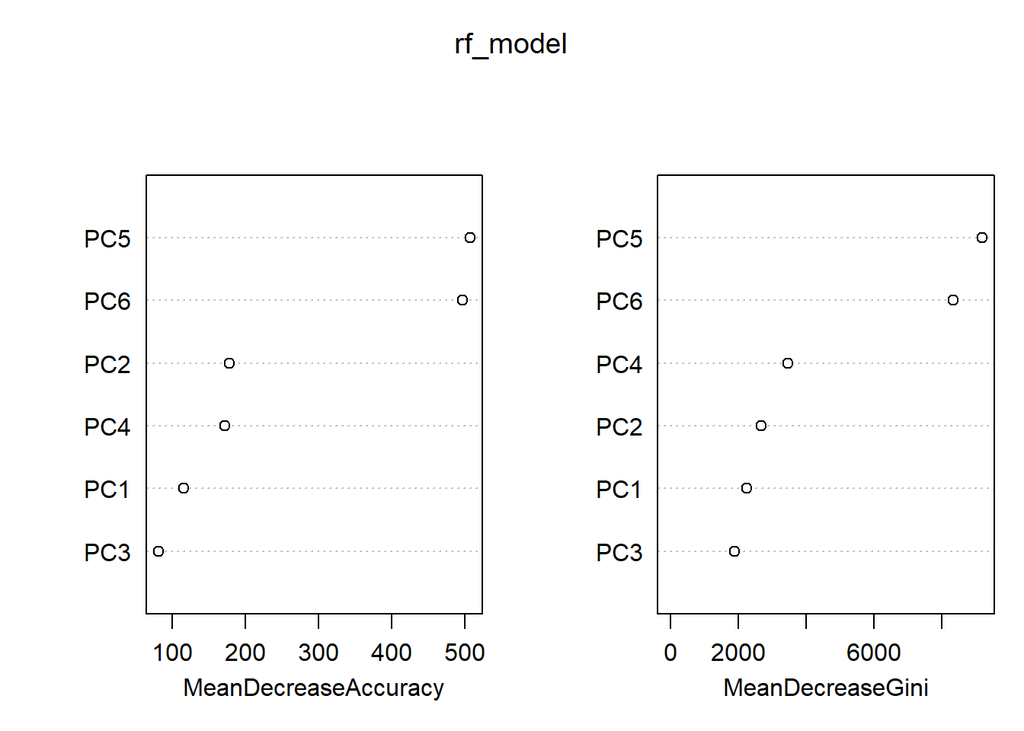

```r
# Plot the importance of components
varImpPlot(rf_model)
```

- PC5 and PC6 are the most important components for predicting all delay categories, as they have the highest importance values across “No Delay,” “Short Delay,” “Long Delay,” and “Very Long Delay.”
- PC5 and PC6 show the highest MeanDecreaseAccuracy scores (506.7 and 496.5, respectively), indicating they have the greatest impact on overall model performance.

This analysis shows that the RF model relies heavily on specific PCs, likely reflecting key patterns in the dataset.